# sesiones

Nestor Flores Castañeda

2023-05-19

# sesiones

## sesion 1-2

Mostrar numeros

```r
x <- c(1,12,30,54,5);
print(x)
```

```
## [1]  1 12 30 54  5
```

```r
y <- runif(10,0,100)
print(y)
```

```
##  [1] 15.69618525 31.12380463 95.02436069 55.16292986 27.26589818  0.02162545
##  [7] 89.21633780 67.75128625 95.17051366 72.58661943
```

```r
y <- floor(y); print(y)
```

```
##  [1] 15 31 95 55 27  0 89 67 95 72
```

Numeros aleatorios en variable entre 0-100 y operaciones

```r
k <- floor(runif(1,0,100)); print(k)
```

```
## [1] 73
```

```r
z <- k+y; print(z)
```

```
##  [1]  88 104 168 128 100  73 162 140 168 145
```

```r
x1 <- floor(runif(15,0,50))
x2 <- ceiling(runif(15,0,50))

y1 <- x1+x2; y1
```

```
##  [1] 54 57 83 57 41 36 28 43 60 32 79 52 57 72 70
```

```r
y2 <- x1-x2;y2
```

```
##  [1] -38  -3  -3   7 -25  10  20 -39 -18 -32 -15   0 -19 -10  18
```

```r
y3 <- x1*x2;y3
```

```
##  [1]  368  810 1720  800  264  299   96   82  819    0 1504  676  722 1271 1144
```

```r
w <- floor(runif(200,-30,100));
print(w)
```

```
##   [1]  25  84 -16  60  32  15   3  34  38  14   7  -6   3  97  28  17   9 -21
##  [19]  66  57 -12  15  38 -18   6  40 -20  66  96  19  89  57 -27  13 -23  -7
##  [37]  49  82  70  44  28  49  -1  12  48  95  49 -17  75  24  71  44  -1  33
##  [55]  46 -20  91  15  48  -2  14  68  12  19 -10  66  52  12   4 -26  -3   3
##  [73]  43  61  54 -16  33  36  84  54 -19  40  82  42   7  96  12  -9 -12  -5
##  [91]  92  41  38  90  58   9 -11  65  33  61  62  61  80   5  -6  32  86  45
## [109]   3  10  33 -19 -17  36  -2  22  42  26  96  11  -6   6  49  50  88  23
## [127]  53  10  58   1  33  78  79  31  64  50  53  25 -23  22  22  22  31  83
## [145]  46  -9  44  71  69   0 -26  80  64   0  23  36  26  34 -24 -13  36 -20
## [163]  98  -3  73 -19  -4  48  -4 -29 -23  83 -10  46  26  34  81 -14   9 -27
## [181]  70  18  22 -17  81  73  76  26  40  27  47  87 -21 -25  87 -13  25  78
## [199]  24  11
```

```r
head(w,30)
```

```
##  [1]  25  84 -16  60  32  15   3  34  38  14   7  -6   3  97  28  17   9 -21  66
## [20]  57 -12  15  38 -18   6  40 -20  66  96  19
```

```r
tail(w,30)
```

```
##  [1] -23  83 -10  46  26  34  81 -14   9 -27  70  18  22 -17  81  73  76  26  40
## [20]  27  47  87 -21 -25  87 -13  25  78  24  11
```

Matriz de 5x5 con valores alatorios y nombres en comlumnas y filas

```r
n <- 5; m <- 5
B <- matrix(0,n,m)
for(i in 1:n){
  for(j in 1:m){
    B[i,j] <- ceiling(runif(1,0,15))
  }
}
print(B)
```

```
##      [,1] [,2] [,3] [,4] [,5]
## [1,]   13    8    4    2    6
## [2,]   10    9    8    3   10
## [3,]   12    6    1   13    5
## [4,]   10   11    1   15    5
## [5,]    3   10    6    8   15
```

```r
View(B)
colnames(B)<- c('Lunes','Martes',
                'Miercoles','Jueves',
                'Viernes')
rownames(B)<- c('Enero','Febrero',
                'Marzo','Abril',
                'Mayo')
B
```

```
##         Lunes Martes Miercoles Jueves Viernes
## Enero      13      8         4      2       6
## Febrero    10      9         8      3      10
## Marzo      12      6         1     13       5
## Abril      10     11         1     15       5
## Mayo        3     10         6      8      15
```

Columna 3 en todas las filas

```r
B[,3]
```

```
##   Enero Febrero   Marzo   Abril    Mayo
##       4       8       1       1       6
```

Fila 3 en todas las columnas

```r
B[3,]
```

```
##     Lunes    Martes Miercoles    Jueves   Viernes
##        12         6         1        13         5
```

De la fila 1 asta la 3

```r
B[1:3,]
```

```
##         Lunes Martes Miercoles Jueves Viernes
## Enero      13      8         4      2       6
## Febrero    10      9         8      3      10
## Marzo      12      6         1     13       5
```

De la columna 1 asta la 3

```r
B[,1:3]
```

```
##         Lunes Martes Miercoles
## Enero      13      8         4
## Febrero    10      9         8
## Marzo      12      6         1
## Abril      10     11         1
## Mayo        3     10         6
```

Fila 2 y fila 4

```r
indices <- c(2,4)
B[indices,]
```

```
##         Lunes Martes Miercoles Jueves Viernes
## Febrero    10      9         8      3      10
## Abril      10     11         1     15       5
```

Coluna 2 y columna 4

```r
indices <- c(2,4)
B[,indices]
```

```
##         Martes Jueves
## Enero        8      2
## Febrero      9      3
## Marzo        6     13
## Abril       11     15
## Mayo        10      8
```

matriz 7x7 meses y dias de la semana

```r
n <- 7
m <- 7
B <- matrix(0,n,m)
for(i in 1:n){
  for(j in 1:m){
    B[i,j] <- floor(runif(1,0,15));
  }
}
B
```

```
##      [,1] [,2] [,3] [,4] [,5] [,6] [,7]
## [1,]    7    5    0   11    2   12    6
## [2,]   14   13    9   12    4    3    1
## [3,]    5   14    9    7    8   13    2
## [4,]    3   14   10    5   13    6    0
## [5,]    6   12    7    9   11    0    4
## [6,]    9    1    0    5    7    2   13
## [7,]    1   13    8    8    0   12    8
```

```r
colnames(B) <- c('Lunes','Martes','Miercoles',
                 'jueves','Viernes','Sabado',
                 'Domingo')
rownames(B) <- c('Enero','Febrero','Marzo',
                 'Abril','Mayo','Junio',
                 'Julio')
B
```

```
##         Lunes Martes Miercoles jueves Viernes Sabado Domingo
## Enero       7      5         0     11       2     12       6
## Febrero    14     13         9     12       4      3       1
## Marzo       5     14         9      7       8     13       2
## Abril       3     14        10      5      13      6       0
## Mayo        6     12         7      9      11      0       4
## Junio       9      1         0      5       7      2      13
## Julio       1     13         8      8       0     12       8
```

```r
indRenglonPar   <- c(2,4,6)
indRenglonImpar <- c(1,3,5,7)
indColPar       <- c(2,4,6)
indColImpar     <- c(1,3,5,7)
```

Las filas de 1 a 3 y columnas de la 1 a la 4

```r
M1 <- B[1:3,1:4]
M1
```

```
##         Lunes Martes Miercoles jueves
## Enero       7      5         0     11
## Febrero    14     13         9     12
## Marzo       5     14         9      7
```

filas dela 4 a la 7 y columnas de la 4 a la 7

```r
M2 <- B[4:7,4:7]
M2
```

```
##       jueves Viernes Sabado Domingo
## Abril      5      13      6       0
## Mayo       9      11      0       4
## Junio      5       7      2      13
## Julio      8       0     12       8
```

todas las filas y columnas impares

```r
M3 <- B[,indColImpar]
M3
```

```
##         Lunes Miercoles Viernes Domingo
## Enero       7         0       2       6
## Febrero    14         9       4       1
## Marzo       5         9       8       2
## Abril       3        10      13       0
## Mayo        6         7      11       4
## Junio       9         0       7      13
## Julio       1         8       0       8
```

filas pares y todas las columnas

```r
M4 <- B[indRenglonPar,]
M4
```

```
##         Lunes Martes Miercoles jueves Viernes Sabado Domingo
## Febrero    14     13         9     12       4      3       1
## Abril       3     14        10      5      13      6       0
## Junio       9      1         0      5       7      2      13
```

fias y columnas impareS

```r
M5 <- B[indRenglonImpar,indColImpar]
M5
```

```
##       Lunes Miercoles Viernes Domingo
## Enero     7         0       2       6
## Marzo     5         9       8       2
## Mayo      6         7      11       4
## Julio     1         8       0       8
```

filas y columnas pares

```r
M6 <- B[indRenglonPar,indColPar]
M6
```

```
##         Martes jueves Sabado
## Febrero     13     12      3
## Abril       14      5      6
## Junio        1      5      2
```

filas pares y columnas impares

```r
M7 <- B[indRenglonPar,indColImpar]
M7
```

```
##         Lunes Miercoles Viernes Domingo
## Febrero    14         9       4       1
## Abril       3        10      13       0
## Junio       9         0       7      13
```

CREAR 4 MATRICES (floor, ceiling, trunc, round)

```r
n <- 7; m <- 7
A1 <- matrix(0,n,m)
A2 <- matrix(0,n,m)
A3 <- matrix(0,n,m)
A4 <- matrix(0,n,m)
for(i in 1:n){
  for(j in 1:m){
    entrada <- runif(1,-50,50)
    A1[i,j] <- floor(entrada)
    A2[i,j] <- ceiling(entrada)
    A3[i,j] <- trunc(entrada)
    A4[i,j] <- round(entrada)
  }
}
A1
```

```
##      [,1] [,2] [,3] [,4] [,5] [,6] [,7]
## [1,]   13  -20   -5   32    3    6  -43
## [2,]   29   24   47  -14  -26  -25  -15
## [3,]  -24  -47   42   43   43  -19   11
## [4,]  -30  -37  -15  -22   -9  -36  -38
## [5,]   16   12   33   -7   -4    2  -48
## [6,]   21  -49  -45   30  -31  -39  -27
## [7,]  -23   36   32   47  -20  -37  -36
```

```r
A2
```

```
##      [,1] [,2] [,3] [,4] [,5] [,6] [,7]
## [1,]   14  -19   -4   33    4    7  -42
## [2,]   30   25   48  -13  -25  -24  -14
## [3,]  -23  -46   43   44   44  -18   12
## [4,]  -29  -36  -14  -21   -8  -35  -37
## [5,]   17   13   34   -6   -3    3  -47
## [6,]   22  -48  -44   31  -30  -38  -26
## [7,]  -22   37   33   48  -19  -36  -35
```

```r
A3
```

```
##      [,1] [,2] [,3] [,4] [,5] [,6] [,7]
## [1,]   13  -19   -4   32    3    6  -42
## [2,]   29   24   47  -13  -25  -24  -14
## [3,]  -23  -46   42   43   43  -18   11
## [4,]  -29  -36  -14  -21   -8  -35  -37
## [5,]   16   12   33   -6   -3    2  -47
## [6,]   21  -48  -44   30  -30  -38  -26
## [7,]  -22   36   32   47  -19  -36  -35
```

```r
A4
```

```
##      [,1] [,2] [,3] [,4] [,5] [,6] [,7]
## [1,]   13  -20   -5   33    3    7  -43
## [2,]   29   25   47  -14  -25  -24  -15
## [3,]  -24  -47   43   43   44  -18   12
## [4,]  -29  -36  -14  -22   -8  -36  -38
## [5,]   16   13   33   -7   -4    2  -47
## [6,]   21  -48  -45   31  -30  -39  -27
## [7,]  -22   37   32   47  -20  -37  -35
```

Operaciones con matrices

```r
A4-A1
```

```
##      [,1] [,2] [,3] [,4] [,5] [,6] [,7]
## [1,]    0    0    0    1    0    1    0
## [2,]    0    1    0    0    1    1    0
## [3,]    0    0    1    0    1    1    1
## [4,]    1    1    1    0    1    0    0
## [5,]    0    1    0    0    0    0    1
## [6,]    0    1    0    1    1    0    0
## [7,]    1    1    0    0    0    0    1
```

```r
A4-A2
```

```
##      [,1] [,2] [,3] [,4] [,5] [,6] [,7]
## [1,]   -1   -1   -1    0   -1    0   -1
## [2,]   -1    0   -1   -1    0    0   -1
## [3,]   -1   -1    0   -1    0    0    0
## [4,]    0    0    0   -1    0   -1   -1
## [5,]   -1    0   -1   -1   -1   -1    0
## [6,]   -1    0   -1    0    0   -1   -1
## [7,]    0    0   -1   -1   -1   -1    0
```

```r
A4-A3
```

```
##      [,1] [,2] [,3] [,4] [,5] [,6] [,7]
## [1,]    0   -1   -1    1    0    1   -1
## [2,]    0    1    0   -1    0    0   -1
## [3,]   -1   -1    1    0    1    0    1
## [4,]    0    0    0   -1    0   -1   -1
## [5,]    0    1    0   -1   -1    0    0
## [6,]    0    0   -1    1    0   -1   -1
## [7,]    0    1    0    0   -1   -1    0
```

se compararn valores para la matriz(==,<=,>=)

```r
D <-  matrix(0,n,m)
L <-  matrix(0,n,m)
U <-  matrix(0,n,m)
for(i in 1:n){
  for(j in 1:m){
    if(i==j){D[i,j]<- ceiling(runif(1,-50,50))}
    if(j<=i){L[i,j]<- ceiling(runif(1,-50,50))}
    if(j>=i){U[i,j]<- ceiling(runif(1,-50,50))}
  }
}
print(D)
```

```
##      [,1] [,2] [,3] [,4] [,5] [,6] [,7]
## [1,]   50    0    0    0    0    0    0
## [2,]    0  -23    0    0    0    0    0
## [3,]    0    0   21    0    0    0    0
## [4,]    0    0    0   33    0    0    0
## [5,]    0    0    0    0   16    0    0
## [6,]    0    0    0    0    0   43    0
## [7,]    0    0    0    0    0    0   -5
```

```r
print(L)
```

```
##      [,1] [,2] [,3] [,4] [,5] [,6] [,7]
## [1,]    0    0    0    0    0    0    0
## [2,]   23  -25    0    0    0    0    0
## [3,]  -24   17    6    0    0    0    0
## [4,]   36  -28   34    2    0    0    0
## [5,]   29  -46  -30  -15   18    0    0
## [6,]   41   31    9   45  -28   -7    0
## [7,]   18  -49    9  -30   25   44   17
```

```r
print(U)
```

```
##      [,1] [,2] [,3] [,4] [,5] [,6] [,7]
## [1,]   -9  -32  -31  -39   -4  -11  -26
## [2,]    0  -17  -10  -39   25  -12  -13
## [3,]    0    0   16   41   30   21   40
## [4,]    0    0    0  -39   27  -20   -6
## [5,]    0    0    0    0  -13  -25  -16
## [6,]    0    0    0    0    0   -8  -23
## [7,]    0    0    0    0    0    0    1
```

```r
L <-  matrix(0,n,m)
for(i in 1:n){
  for(j in 1:i){
    L[i,j]<- ceiling(runif(1,-50,50))
  }
}
print(L)
```

```
##      [,1] [,2] [,3] [,4] [,5] [,6] [,7]
## [1,]   45    0    0    0    0    0    0
## [2,]   21   -5    0    0    0    0    0
## [3,]  -46   13  -16    0    0    0    0
## [4,]  -15   17   38   -2    0    0    0
## [5,]  -16  -19  -10  -46   17    0    0
## [6,]    8   41   41   34   38   29    0
## [7,]   32  -36  -27  -42   27   -5   13
```

```r
for(i in 1:n){
  for(j in i:m){
    U[i,j]<- ceiling(runif(1,-50,50))
  }
}
print(U)
```

```
##      [,1] [,2] [,3] [,4] [,5] [,6] [,7]
## [1,]    6    9    0    1   48  -33   -8
## [2,]    0   -8  -49  -17  -30  -35   41
## [3,]    0    0  -16  -44   50  -31   10
## [4,]    0    0    0   30   -6  -24  -17
## [5,]    0    0    0    0    3   33   26
## [6,]    0    0    0    0    0   -9   25
## [7,]    0    0    0    0    0    0  -22
```

varianza

```r
n <- 13
x <- matrix(0,1,n)
for(i in 1:n){
  x[i] <- round(runif(1,0,100))
}
x
```

```
##      [,1] [,2] [,3] [,4] [,5] [,6] [,7] [,8] [,9] [,10] [,11] [,12] [,13]
## [1,]   65   22    4   67   71    0   26   22   12    95    71    18    38
```

```r
suma   <- 0
xbarra <- 0
for(i in 1:n){
  suma <- suma + x[i]
}
xbarra <- suma/n
suma2    <- 0
varianza <- 0
for(i in 1:n){
  termino <- x[i]-xbarra
  termino2 <- termino^2
  suma2 <- suma2 + termino2
}
varianza <- suma2/(n-1);varianza
```

```
## [1] 942.2308
```

# sesion 3

se simula una base detatos de cierto tamaño

```r
NumVar     <- 150   # numero de datos a generar
NumMuestra <- 30    # NUMERO DE MUESTRAS A CONSIDERAR
Datos <- matrix(0,NumVar,NumMuestra); head(Datos)
```

```
##      [,1] [,2] [,3] [,4] [,5] [,6] [,7] [,8] [,9] [,10] [,11] [,12] [,13] [,14]
## [1,]    0    0    0    0    0    0    0    0    0     0     0     0     0     0
## [2,]    0    0    0    0    0    0    0    0    0     0     0     0     0     0
## [3,]    0    0    0    0    0    0    0    0    0     0     0     0     0     0
## [4,]    0    0    0    0    0    0    0    0    0     0     0     0     0     0
## [5,]    0    0    0    0    0    0    0    0    0     0     0     0     0     0
## [6,]    0    0    0    0    0    0    0    0    0     0     0     0     0     0
##      [,15] [,16] [,17] [,18] [,19] [,20] [,21] [,22] [,23] [,24] [,25] [,26]
## [1,]     0     0     0     0     0     0     0     0     0     0     0     0
## [2,]     0     0     0     0     0     0     0     0     0     0     0     0
## [3,]     0     0     0     0     0     0     0     0     0     0     0     0
## [4,]     0     0     0     0     0     0     0     0     0     0     0     0
## [5,]     0     0     0     0     0     0     0     0     0     0     0     0
## [6,]     0     0     0     0     0     0     0     0     0     0     0     0
##      [,27] [,28] [,29] [,30]
## [1,]     0     0     0     0
## [2,]     0     0     0     0
## [3,]     0     0     0     0
## [4,]     0     0     0     0
## [5,]     0     0     0     0
## [6,]     0     0     0     0
```

Se simula base de datos

```r
for(i in 1:NumMuestra){
  Datos[,i] <- round(runif(NumVar, 30,50));
}
View(Datos)
```

Se determina las medias de tendencia central y de dispersion para cada una de las muestras media para la muestra

```r
X1 <- Datos[,1]; head(X1)
```

```
## [1] 38 39 42 36 32 48
```

```r
suma <- 0
for(i in 1:NumVar){
  suma <- suma + X1[i]
}
PromedioX1 <- suma/NumVar
```

se calcula la moda

```r
contando <- table(X1); print(contando)
```

```
## X1
## 30 31 32 33 34 35 36 37 38 39 40 41 42 43 44 45 46 47 48 49 50
##  2  6  8  4  7 11  7  6  9  7  8  8  9  6 10  6  9 11  9  5  2
```

```r
ordenado <- sort(contando)
n <- length(ordenado)
modaX1 <- ordenado[n]
modaX1
```

```
## 47
## 11
```

Se obtiene la mediana

```r
N <- length(X1)
N
```

```
## [1] 150
```

se determina si la cantidad es par o impar

```r
if( N%%2==0){
  print('ES UN NUMERO PAR DE DATOS')
  X1Ord <- sort(X1) # ESTA INSTRUCCION ORDENA DE MENOR A MAYOR.
  primero <- X1Ord[N/2]   # OBTENEMOS EL DATO QUE ESTA AL FINAL DE LOS PRIMEROS n/2 DATOS
  segundo <- X1Ord[N/2+1] # OBTENEMOS EL DATO QUE ESTA AL INICIO DE LOS SEGUNDOS n/2 DATOS
  medianaX1 <- (primero+segundo)/2
}else{
  X1Ord <- sort(X1) # ESTA INSTRUCCION ORDENA DE MENOR A MAYOR.
  medianaX1 <- X1Ord[N/2+1] # OBTENEMOS EL DATO QUE ESTA A LA MITAD DE LOS DATOS

}
```

```
## [1] "ES UN NUMERO PAR DE DATOS"
```

Media,mediama,moda.

```r
MTC <- matrix(0,1,3)
MTC[1,1] <- PromedioX1
MTC[1,2] <- medianaX1
MTC[1,3] <- modaX1
colnames(MTC) <- c('Media','Mediana','Moda'); print(MTC)
```

```
##      Media Mediana Moda
## [1,] 40.32    40.5   11
```

CALCULEMOS AHORA LA PRINCIPAL MEDIDA DE DISPERSION

```r
suma <- 0;
for(i in 1:NumVar){
  termino1 <- X1[i]-PromedioX1
  termino12 <- termino1^2
  suma <- suma + termino12
}
Varianza <- suma/(NumVar-1)
DesvEst <- sqrt(Varianza)
print(DesvEst)
```

```
## [1] 5.536117
```

# sesion 4

REGRECCION INEAL Se simula una base de datos con 150 realizaciones en cada muestra, y 30 muestras.

```r
NumVar     <- 150
NumMuestra <- 30
Datos <- matrix(0,NumVar,NumMuestra)
for(i in 1:NumMuestra){Datos[,i]<- round(runif(NumVar,30,50));}
head(Datos,15)
```

```
##       [,1] [,2] [,3] [,4] [,5] [,6] [,7] [,8] [,9] [,10] [,11] [,12] [,13]
##  [1,]   44   47   44   43   32   34   48   44   46    48    49    33    43
##  [2,]   46   44   33   46   44   43   32   36   41    37    34    38    37
##  [3,]   43   44   40   36   40   34   38   43   30    50    39    47    35
##  [4,]   35   48   45   42   48   41   36   42   36    33    44    38    44
##  [5,]   48   46   46   37   35   41   45   36   39    43    32    36    42
##  [6,]   49   41   39   48   30   37   37   47   41    36    45    32    45
##  [7,]   35   39   36   45   30   41   49   44   36    32    32    43    39
##  [8,]   37   34   46   33   40   32   44   31   40    47    41    43    32
##  [9,]   40   34   41   43   47   47   33   47   46    33    45    34    46
## [10,]   35   31   36   43   46   37   40   40   44    31    46    46    36
## [11,]   31   33   44   43   41   38   46   30   36    32    37    35    33
## [12,]   34   32   39   34   47   41   49   36   32    44    42    38    40
## [13,]   36   34   38   39   38   48   31   45   44    36    34    38    47
## [14,]   37   47   38   49   49   43   43   35   37    31    37    45    48
```

[output cut: 33 more lines]

```r
x1<- abs(round(rnorm(NumVar,0,50)));x1
```

```
##   [1]  62   9  59  88  45  46  88  40  10  49  15 119 111   2  62  54  20  41
##  [19]  22  56  42  61  14  37  18  24   2  21  29  43   2  24  68  48  22   0
##  [37]  42  76  58  24  63   6  68  42  19 117  45  28  15 105  21  45   4  61
##  [55]  23  66   0  17  27 119  16  12  58  11   8  73   4  41  27   0   5  31
##  [73]   4  69  26  50  37  75  25  55  71  45  26  53  25  44   4  56  49  21
##  [91]  31  74  66  63  13  37  29  30   5  32  47  25 100  15  22  58  42  21
## [109]   5  46   4  13  97  69  36 129  61  21  17  23  34  25  30   9  69   8
## [127] 102  34  33  16  74  80  14  21  24  28  11  63   2  46  29 115  45  35
## [145]  26  61  23  22  86  31
```

```r
Datos <- cbind(x1,Datos); head(Datos,15);
```

```
##        x1
##  [1,]  62 44 47 44 43 32 34 48 44 46 48 49 33 43 42 46 39 47 49 48 33 43 41 45
##  [2,]   9 46 44 33 46 44 43 32 36 41 37 34 38 37 40 31 42 34 47 34 31 38 36 41
##  [3,]  59 43 44 40 36 40 34 38 43 30 50 39 47 35 44 33 33 40 40 47 36 38 45 32
##  [4,]  88 35 48 45 42 48 41 36 42 36 33 44 38 44 40 38 36 32 46 46 38 49 46 46
##  [5,]  45 48 46 46 37 35 41 45 36 39 43 32 36 42 40 37 41 45 47 32 37 41 43 34
##  [6,]  46 49 41 39 48 30 37 37 47 41 36 45 32 45 33 46 30 30 38 41 32 32 35 42
##  [7,]  88 35 39 36 45 30 41 49 44 36 32 32 43 39 43 35 36 42 43 47 47 32 39 31
##  [8,]  40 37 34 46 33 40 32 44 31 40 47 41 43 32 38 35 47 50 43 30 39 40 39 37
##  [9,]  10 40 34 41 43 47 47 33 47 46 33 45 34 46 35 37 37 33 50 36 36 35 46 42
## [10,]  49 35 31 36 43 46 37 40 40 44 31 46 46 36 43 33 47 38 40 49 40 49 36 34
## [11,]  15 31 33 44 43 41 38 46 30 36 32 37 35 33 38 33 36 42 40 47 33 48 49 34
## [12,] 119 34 32 39 34 47 41 49 36 32 44 42 38 40 40 50 46 45 47 46 30 48 47 40
## [13,] 111 36 34 38 39 38 48 31 45 44 36 34 38 47 41 46 45 31 43 49 41 33 35 40
## [14,]   2 37 47 38 49 49 43 43 35 37 31 37 45 48 48 42 50 32 30 36 49 48 36 31
```

[output cut: 17 more lines]

consideramos las primeras dos muestras

```r
X<-Datos[,2]; Y<-Datos[,3]
```

calculemos la media de cada variebla

```r
suma<-0;for (i in 1:NumVar){suma<-suma+X[i]};xbarra<-suma/NumVar
xbarra
```

```
## [1] 39.90667
```

```r
suma<-0;for (i in 1:NumVar){suma<-suma+Y[i]};ybarra<-suma/NumVar;
ybarra
```

```
## [1] 40.12667
```

```r
suma<-0;for (i in 1:NumVar){suma<-suma+(X[i]-xbarra)^2};Sxx<-suma/NumVar;
Sxx
```

```
## [1] 31.20462
```

```r
suma<-0;for (i in 1:NumVar){suma<-suma+(X[i]-xbarra)*(Y[i]-ybarra)};Sxy<-suma/NumVar;
Sxy
```

```
## [1] 2.778489
```

```r
Beta1<- Sxy/Sxx; Beta1
```

```
## [1] 0.08904094
```

```r
Beta0<-ybarra-Beta1*xbarra;Beta0
```

```
## [1] 36.57334
```

para hacer las predicciones

```r
Ygorro<-Beta0+Beta1*X; Ygorro
```

```
##   [1] 40.49114 40.66922 40.40210 39.68977 40.84730 40.93635 39.68977 39.86785
##   [9] 40.13498 39.68977 39.33361 39.60073 39.77881 39.86785 40.04594 39.68977
##  [17] 39.33361 40.93635 39.68977 40.04594 39.77881 40.13498 40.04594 39.24457
##  [25] 39.42265 40.13498 40.66922 40.13498 39.24457 40.40210 40.22402 39.33361
##  [33] 39.60073 40.40210 40.22402 41.02539 40.22402 39.95690 39.33361 40.31306
##  [41] 40.22402 40.04594 40.31306 40.40210 39.33361 40.31306 40.75826 39.77881
##  [49] 40.31306 39.95690 39.51169 40.22402 39.51169 39.51169 39.60073 39.68977
##  [57] 40.13498 40.22402 40.13498 40.58018 40.75826 40.66922 41.02539 40.40210
##  [65] 41.02539 40.22402 40.58018 39.95690 40.13498 39.60073 39.86785 39.95690
##  [73] 39.42265 40.22402 40.75826 40.49114 40.40210 40.31306 39.24457 40.66922
##  [81] 40.13498 39.42265 40.66922 40.93635 39.24457 39.33361 39.51169 39.77881
##  [89] 40.49114 40.40210 40.66922 40.93635 40.04594 40.40210 40.84730 39.68977
##  [97] 40.40210 39.60073 40.58018 40.66922 39.95690 39.77881 39.51169 40.49114
## [105] 40.49114 39.60073 40.22402 40.93635 40.75826 39.60073 40.93635 39.51169
## [113] 40.66922 40.04594 39.24457 40.40210 40.66922 39.86785 40.40210 40.58018
## [121] 40.49114 39.68977 40.49114 41.02539 39.60073 40.31306 40.31306 40.31306
## [129] 40.84730 40.66922 39.42265 40.22402 40.04594 39.33361 39.42265 40.04594
## [137] 40.22402 39.77881 40.75826 39.60073 40.66922 40.40210 40.40210 39.86785
## [145] 39.42265 40.66922 39.60073 40.75826 40.49114 39.77881
```

Error

```r
Error<- Y-Ygorro;Error
```

```
##   [1]   6.50885909   3.33077721   3.59790003   8.31022754   5.15269533
##   [6]   0.06365439  -0.68977246  -5.86785433  -6.13497715  -8.68977246
##  [11]  -6.33360870  -7.60073152  -5.77881340   7.13214567   5.95406379
##  [16]   2.31022754  -4.33360870   1.06365439  -5.68977246   2.95406379
##  [21]   9.22118660  -1.13497715   4.95406379  -7.24456776   0.57735036
##  [26]  -9.13497715  -0.66922279  -5.13497715   7.75543224   4.59790003
##  [31]  -2.22401809   9.66639130  -6.60073152   7.59790003  -0.22401809
##  [36]   8.97461345 -10.22401809   4.04310473  -6.33360870   5.68694097
##  [41]  -4.22401809   3.95406379  -1.31305903  -7.40209997   4.66639130
##  [46]   1.68694097   7.24173627   5.22118660   6.68694097  -1.95689527
##  [51]   5.48830942  -0.22401809   9.48830942   2.48830942  -8.60073152
##  [56]  -3.68977246   3.86502285  -8.22401809  -9.13497715   9.41981815
##  [61]  -8.75826373  -5.66922279  -8.02538655  -9.40209997   4.97461345
##  [66]   7.77598191  -5.58018185   3.04310473  -0.13497715  -9.60073152
##  [71]   1.13214567  -4.95689527  10.57735036   8.77598191   4.24173627
##  [76]  -4.49114091  -7.40209997   8.68694097   1.75543224   4.33077721
##  [81]   5.86502285  -6.42264964  -0.66922279  -7.93634561   8.75543224
##  [86]   7.66639130   4.48830942   6.22118660  -8.49114091   2.59790003
##  [91]   8.33077721   7.06365439  -8.04593621   5.59790003  -3.84730467
##  [96]   1.31022754   6.59790003  10.39926848  -8.58018185  -9.66922279
## [101]  -1.95689527  -7.77881340  -0.51169058  -2.49114091   1.50885909
## [106]  -5.60073152  -9.22401809   0.06365439  -2.75826373   1.39926848
## [111]   3.06365439   4.48830942   9.33077721   5.95406379  -9.24456776
## [116]   1.59790003   5.33077721   7.13214567  -7.40209997   2.41981815
## [121]  -0.49114091  -0.68977246  -4.49114091   0.97461345   9.39926848
## [126]  -6.31305903   0.68694097   7.68694097  -7.84730467   0.33077721
## [131]  -7.42264964  -1.22401809  -5.04593621   7.66639130  -3.42264964
## [136]  -1.04593621  -8.22401809   9.22118660   6.24173627  -5.60073152
## [141]  -6.66922279  -6.40209997  -4.40209997  -0.86785433  -8.42264964
## [146]   5.33077721   2.39926848  -1.75826373   5.50885909  -7.77881340
```

Coeficiente de correlacion metodo 1

```r
suma1 <- 0
suma2 <- 0
for (i in 1:NumVar){
suma1 <- suma1 + X[i]
suma2 <- suma2 + Y[i]
}
xbarra <- suma1 / NumVar
ybarra <- suma2 / NumVar
xbarra
```

```
## [1] 39.90667
```

```r
ybarra
```

```
## [1] 40.12667
```

```r
suma <- 0
for (i in 1:NumVar) {
suma <- suma + (X[i] - xbarra) * (Y[i] - ybarra)
}
nSxy <- suma
nSxy
```

```
## [1] 416.7733
```

```r
suma <- 0
for (i in 1:NumVar) {
suma <- suma + (X[i] - xbarra)^2}
nSxx <- suma
rnSxx <- sqrt(nSxx)
rnSxx
```

```
## [1] 68.41559
```

```r
nSyy <- sum((Y - ybarra)^2)
nSyy
```

```
## [1] 5550.593
```

```r
rxy <- nSxy / (rnSxx * sqrt(nSyy))
rxy
```

```
## [1] 0.08176645
```

Metodo 2

```r
suma <-0
for (i in 1:NumVar){suma <- suma + X[i]*Y[i]}
Ter1<- NumVar*suma; Ter1;
```

```
## [1] 36092250
```

```r
suma1<-0; suma2<-0;for (i in 1:NumVar){suma1<-suma1+X[i]; suma2<-suma2+Y[i]};Ter2<-suma1*suma2;Ter2
```

```
## [1] 36029734
```

```r
Numerador<-Ter1-Ter2;Numerador
```

```
## [1] 62516
```

```r
suma<-0; for (i in 1:NumVar){suma<-suma+(X[i])^2};
Ter1<-NumVar*suma-(NumVar*xbarra)^2; raiz1<-sqrt(Ter1);
suma<-0; for (i in 1:NumVar){suma<-suma+(Y[i])^2};
Ter1<-NumVar*suma-(NumVar*ybarra)^2; raiz2<-sqrt(Ter2);
Denominador<- raiz1*raiz2; Denominador
```

```
## [1] 5029575
```

```r
Rxy<-Numerador/Denominador;Rxy
```

```
## [1] 0.01242968
```

## Sesion 6

GRAFICAS

```r
MiRegresion <- function(X,Y) {
  numvar <- length(X);
  suma <- 0;
  for(i in 1:numvar){suma <- suma +X[i]}
  xbarra <- suma/numvar;
  suma <- 0;
  for(i in 1:numvar){suma <- suma +Y[i]}
  ybarra <- suma/numvar;
  suma <- 0;
  for(i in 1:numvar){suma <- suma +(X[i]-xbarra)^2}
  Sxx <- suma/numvar;
  suma <- 0;
  for(i in 1:numvar){suma <- suma+((X[i]-xbarra)*(Y[i]-ybarra))}
  Sxy <- suma/numvar;
  Beta1  <- Sxy/Sxx;
  Beta0  <- ybarra-Beta1*xbarra;
  Ygorro <- Beta0+Beta1*X;
  resultado <- list(beta0 = Beta0,
                    beta1 = Beta1,
                    Yest  = Ygorro)
  return(resultado)
}
```

```r
#----------------------------------------------
NumVar <- 150
NumMuestras <- 30
Datos <- matrix(0,NumVar,NumMuestras); View(Datos)
#----------------------------------------------
set.seed(550)
#----------------------------------------------
for(i in 1:NumMuestras){
  Datos[,i] <- round(runif(NumVar,30,50))
}
View(Datos)
Ind <- abs(round(rnorm(150,24,10))); View(Ind)
MiBDD <- cbind(Ind,Datos); View(MiBDD)
#----------------------------------------------
head(MiBDD,5)
```

```
##      Ind
## [1,]  32 45 40 35 39 36 31 43 37 50 37 41 47 38 38 37 32 45 41 48 35 39 47 31
## [2,]  13 42 38 41 35 31 44 36 40 44 37 35 39 31 31 46 41 41 39 34 31 32 38 49
## [3,]  37 50 47 45 44 48 40 41 41 34 30 40 32 41 37 41 44 46 43 50 38 45 33 35
## [4,]   9 45 49 38 47 36 45 38 31 38 32 36 46 42 49 37 31 42 38 46 34 34 37 47
## [5,]  14 49 36 44 41 39 44 45 36 48 35 38 35 31 39 46 43 49 32 44 30 37 39 39
##
## [1,] 39 31 40 49 45 44 46
## [2,] 42 38 42 33 49 45 43
## [3,] 33 35 48 36 47 49 35
## [4,] 50 30 50 48 50 41 36
## [5,] 33 49 42 36 46 35 36
```

```r
#----------------------------------------------
X <- MiBDD[,1]; head(X,15)
```

```
##  [1] 32 13 37  9 14 21 13 28 33 26 32 17 20 24 12
```

```r
Y <- MiBDD[,2]; head(Y,15)
```

```
##  [1] 45 42 50 45 49 30 47 44 38 38 46 34 35 47 50
```

```r
#----------------------------------------------
contando <- table(X); print(contando)
```

```
## X
##  0  5  7  8  9 10 11 12 13 14 15 16 17 18 19 20 21 22 23 24 25 26 27 28 29 30
##  1  1  3  2  2  1  3  2  3  2  2  5  6  2  2 12  6  8  3  5  2  7  7  6 12  8
## 31 32 33 34 35 36 37 38 39 40 41 42 44 46
##  3  5  1  5  3  2  5  3  2  2  1  2  2  1
```

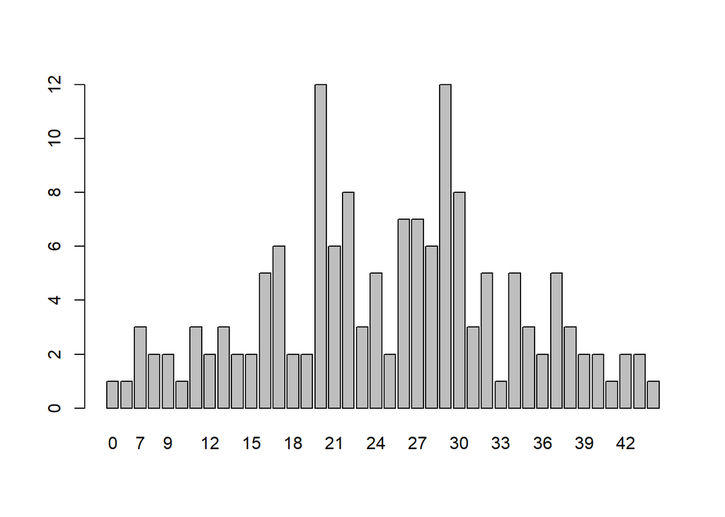

```r
#----------------------------------------------
barplot(contando)
```

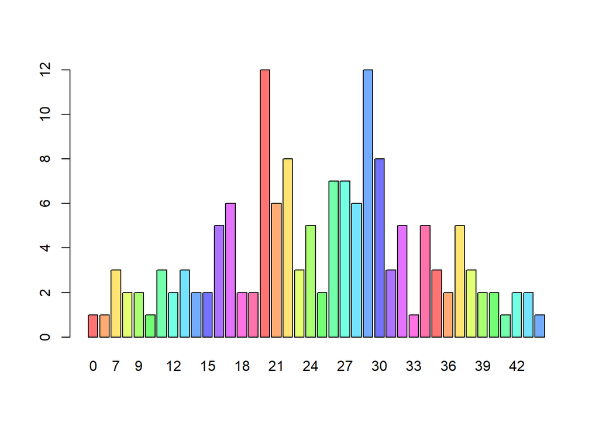

```r
barplot(contando,
        col=rainbow(15,0.55))
```

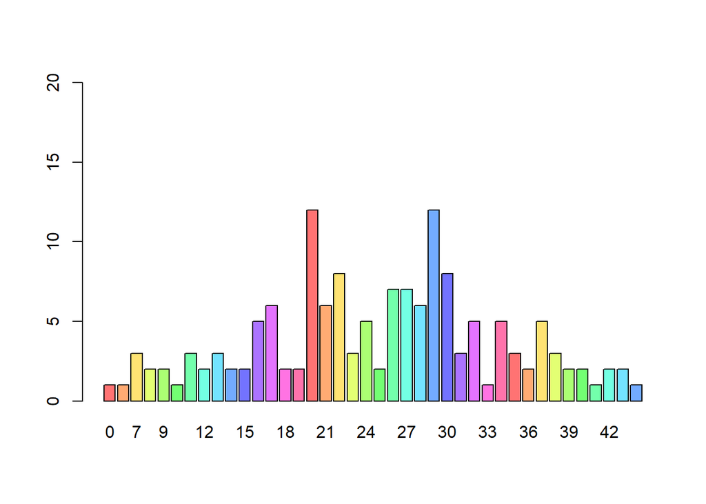

```r
barplot(contando,
        col=rainbow(15,0.55),
        ylim = c(0,20))
```

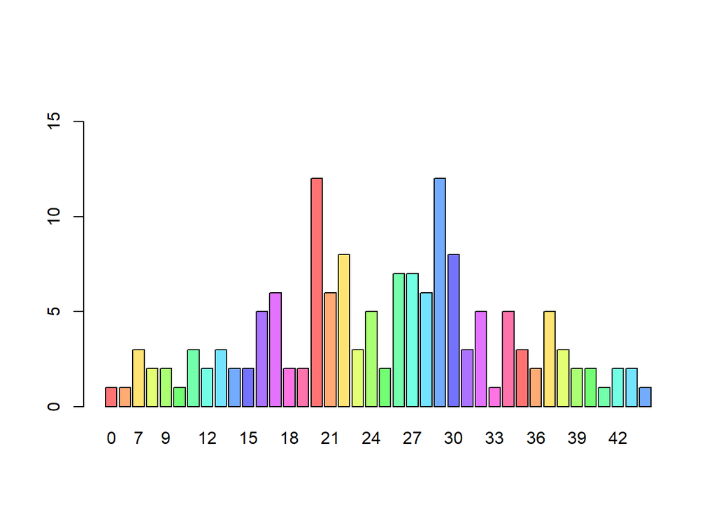

```r
barplot(contando,
        col=rainbow(15,0.55),
        ylim = c(0,17))
```

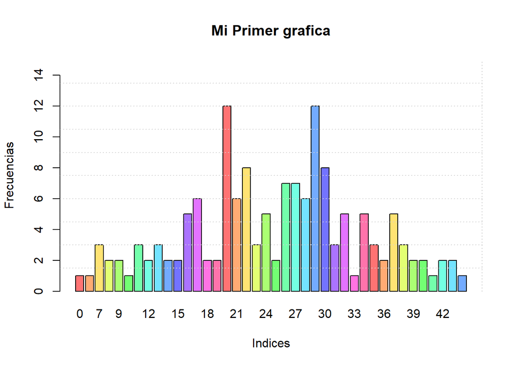

```r
barplot(contando,
        col=rainbow(15,0.55),
        ylim = c(0,15),
        xlab = 'Indices',
        ylab = 'Frecuencias',
        main = 'Mi Primer grafica')
grid(1.5,10)
```

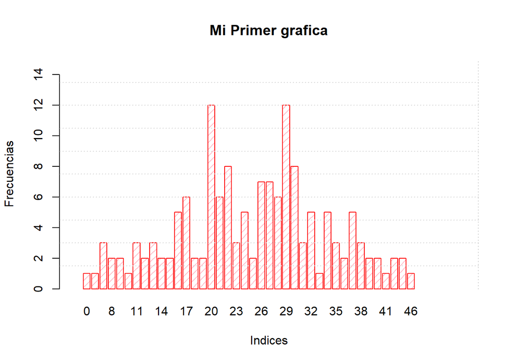

```r
barplot(contando,
        col  = 'pink',#rainbow(15,0.55),
        ylim = c(0,15),
        xlim = c(-1,55),
        xlab = 'Indices',
        ylab = 'Frecuencias',
        border="red",
        main = 'Mi Primer grafica',
        density = 15)
grid(1.5,10)
```

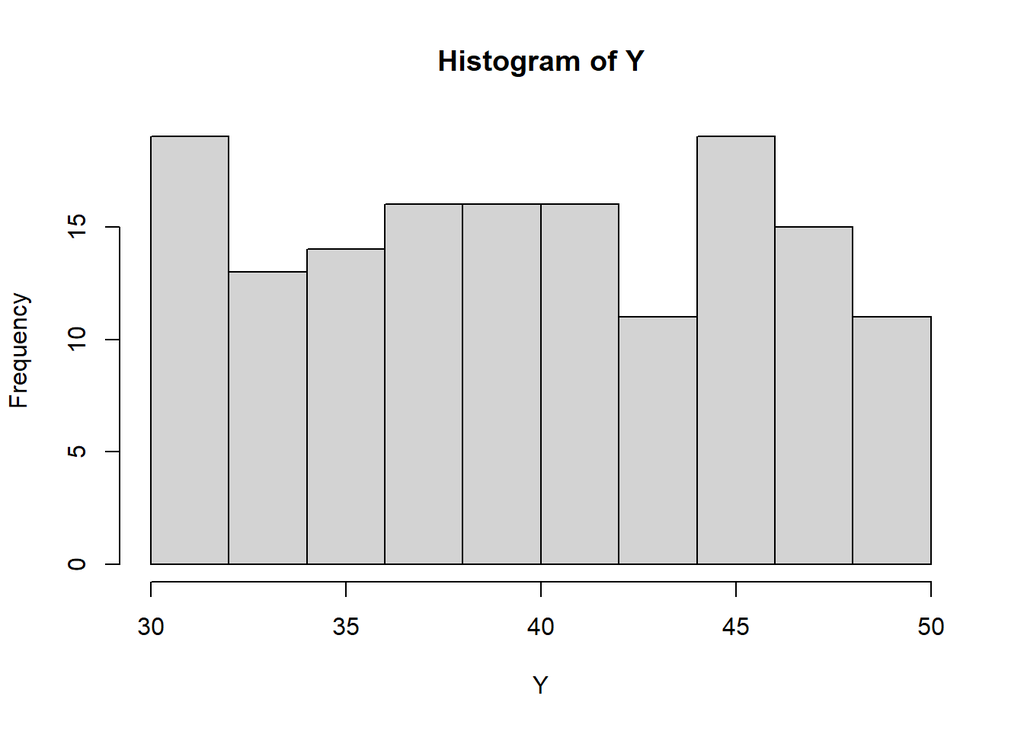

```r
#----------------------------------------------
nbreaks = 15
hist(Y)
```

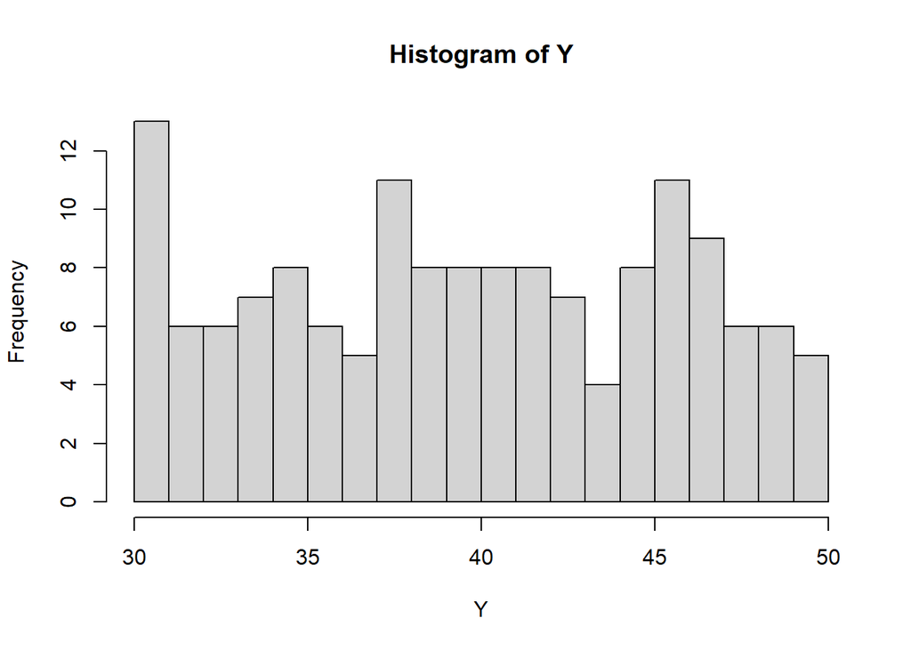

```r
hist(Y,breaks=nbreaks)
```

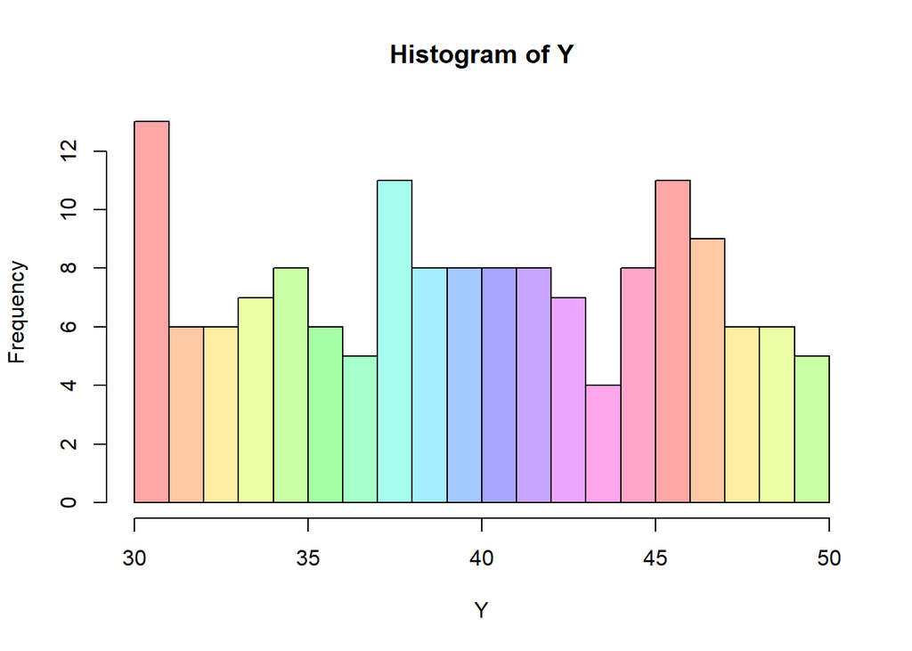

```r
hist(Y,breaks=nbreaks,
     col=rainbow(15,0.35))
```

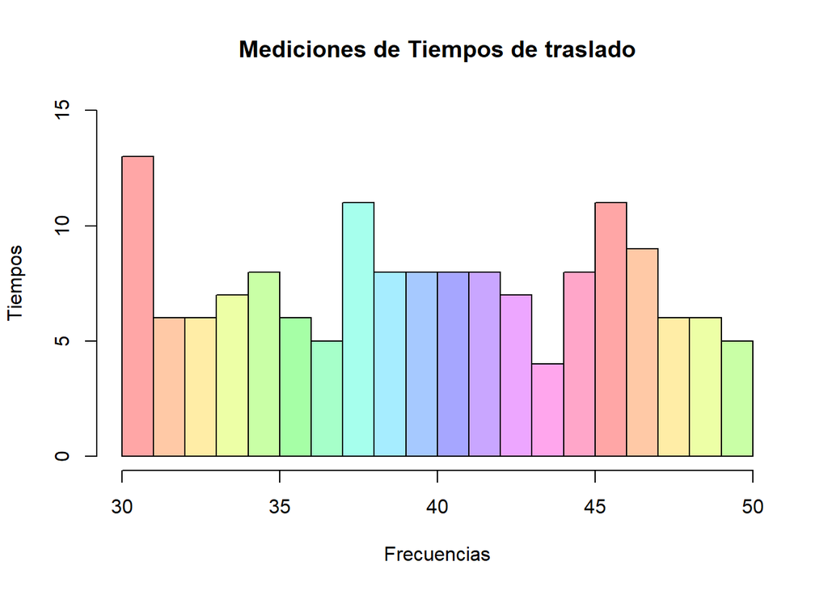

```r
hist(Y,breaks=nbreaks,
     col=rainbow(15,0.35),
     main = 'Mediciones de Tiempos de traslado',
     xlab = 'Frecuencias',
     ylab = 'Tiempos',
     ylim = c(0,15))
```

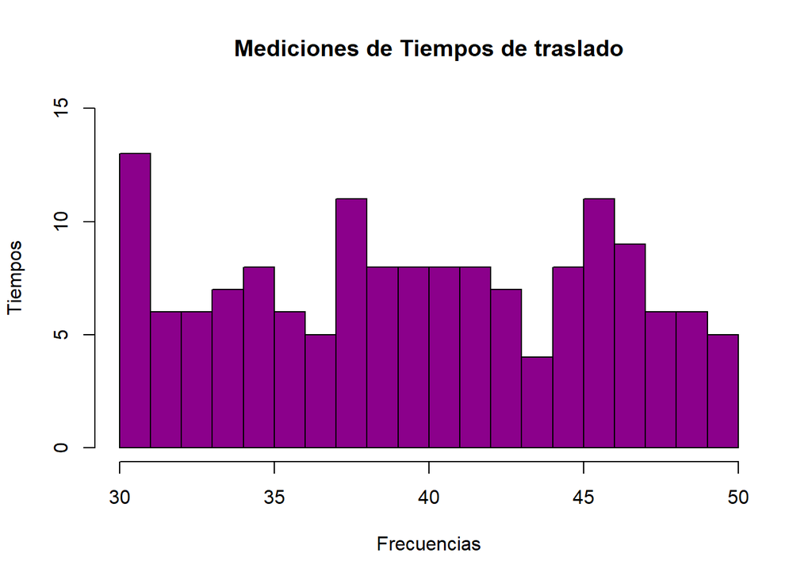

```r
hist(Y,breaks=nbreaks,
#     col=rainbow(15,0.35),
     main = 'Mediciones de Tiempos de traslado',
     xlab = 'Frecuencias',
     ylab = 'Tiempos',
     ylim = c(0,15),
     col="darkmagenta",
     freq=TRUE)
```

```r
Temperature <- Y


h <- hist(Temperature,breaks=nbreaks,
          col=rainbow(15,0.35),
          main = 'Mediciones de Tiempos de traslado',
          xlab = 'Frecuencias',
          ylab = 'Tiempos',
          ylim = c(0,15),
          freq=TRUE)
summary(h)
```

```
##          Length Class  Mode
## breaks   21     -none- numeric
## counts   20     -none- numeric
## density  20     -none- numeric
## mids     20     -none- numeric
## xname     1     -none- character
## equidist  1     -none- logical
```

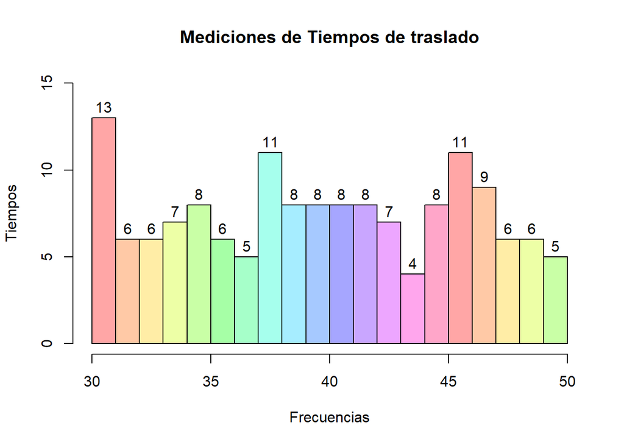

```r
text(h$mids,h$counts,
     labels=h$counts, adj=c(0.5, -0.5))
```

```r
h <- hist(Temperature,breaks=nbreaks,
          col=rainbow(15,0.35),
          main = 'Mediciones de Tiempos de traslado',
          xlab = 'Frecuencias',
          ylab = 'Tiempos',
          ylim = c(0,15),
          freq=TRUE)
summary(h)
```

```
##          Length Class  Mode
## breaks   21     -none- numeric
## counts   20     -none- numeric
## density  20     -none- numeric
## mids     20     -none- numeric
## xname     1     -none- character
## equidist  1     -none- logical
```

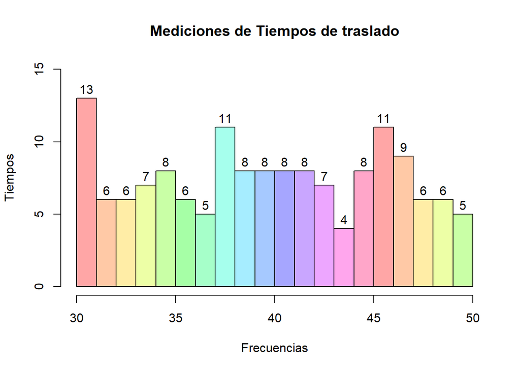

```r
text(h$mids,h$counts,
     labels=h$counts, adj=c(0.5, -0.5))
```

```r
pdf("MiGrafica1.pdf")
h <- hist(Temperature,breaks=nbreaks,
          col=rainbow(15,0.35),
          main = 'Mediciones de Tiempos de traslado',
          xlab = 'Frecuencias',
          ylab = 'Tiempos',
          ylim = c(0,15),
          freq=TRUE)
summary(h)
```

```
##          Length Class  Mode
## breaks   21     -none- numeric
## counts   20     -none- numeric
## density  20     -none- numeric
## mids     20     -none- numeric
## xname     1     -none- character
## equidist  1     -none- logical
```

```r
text(h$mids,h$counts,
     labels=h$counts, adj=c(0.5, -0.5))
dev.off()
```

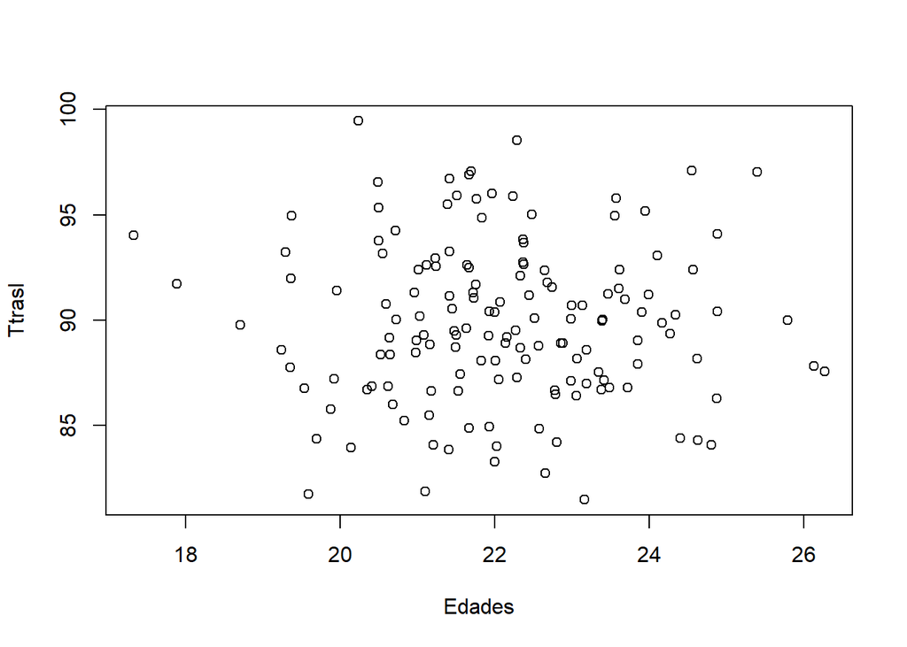

```r
#----------------------------------------------
# simulacion de edades y tiempos de traslado

Edades <- rnorm(NumVar,22,1.5)
Ttrasl <- rnorm(NumVar,90,3.5)
plot(Edades,Ttrasl)
```

# sesion 8

GRAFICAS

```r
set.seed(123)
numvar <- 150;
X <- rnorm(numvar);      print(X)
```

```
##   [1] -0.560475647 -0.230177489  1.558708314  0.070508391  0.129287735
##   [6]  1.715064987  0.460916206 -1.265061235 -0.686852852 -0.445661970
##  [11]  1.224081797  0.359813827  0.400771451  0.110682716 -0.555841135
##  [16]  1.786913137  0.497850478 -1.966617157  0.701355902 -0.472791408
##  [21] -1.067823706 -0.217974915 -1.026004448 -0.728891229 -0.625039268
##  [26] -1.686693311  0.837787044  0.153373118 -1.138136937  1.253814921
##  [31]  0.426464221 -0.295071483  0.895125661  0.878133488  0.821581082
##  [36]  0.688640254  0.553917654 -0.061911711 -0.305962664 -0.380471001
##  [41] -0.694706979 -0.207917278 -1.265396352  2.168955965  1.207961998
##  [46] -1.123108583 -0.402884835 -0.466655354  0.779965118 -0.083369066
##  [51]  0.253318514 -0.028546755 -0.042870457  1.368602284 -0.225770986
##  [56]  1.516470604 -1.548752804  0.584613750  0.123854244  0.215941569
##  [61]  0.379639483 -0.502323453 -0.333207384 -1.018575383 -1.071791226
##  [66]  0.303528641  0.448209779  0.053004227  0.922267468  2.050084686
##  [71] -0.491031166 -2.309168876  1.005738524 -0.709200763 -0.688008616
##  [76]  1.025571370 -0.284773007 -1.220717712  0.181303480 -0.138891362
##  [81]  0.005764186  0.385280401 -0.370660032  0.644376549 -0.220486562
##  [86]  0.331781964  1.096839013  0.435181491 -0.325931586  1.148807618
##  [91]  0.993503856  0.548396960  0.238731735 -0.627906076  1.360652449
##  [96] -0.600259587  2.187332993  1.532610626 -0.235700359 -1.026420900
## [101] -0.710406564  0.256883709 -0.246691878 -0.347542599 -0.951618567
## [106] -0.045027725 -0.784904469 -1.667941937 -0.380226520  0.918996609
## [111] -0.575346963  0.607964322 -1.617882708 -0.055561966  0.519407204
## [116]  0.301153362  0.105676194 -0.640706008 -0.849704346 -1.024128791
## [121]  0.117646597 -0.947474614 -0.490557444 -0.256092192  1.843862005
## [126] -0.651949902  0.235386572  0.077960850 -0.961856634 -0.071308086
## [131]  1.444550858  0.451504053  0.041232922 -0.422496832 -2.053247222
## [136]  1.131337213 -1.460640071  0.739947511  1.909103569 -1.443893161
## [141]  0.701784335 -0.262197489 -1.572144159 -1.514667654 -1.601536174
## [146] -0.530906522 -1.461755585  0.687916773  2.100108941 -1.287030476
```

```r
Y <- 2*X +rnorm(numvar); print(Y)
```

```
##   [1] -0.33321245  0.30868726  3.44961921 -0.86735983  0.13912286  3.14973464
##   [7]  1.48482195 -2.90256123 -0.39673232 -1.26590480  3.50087506 -0.32954935
##  [13] -0.45861234  3.46240537 -1.52853986  3.87205387  1.63227063 -4.41701494
##  [19]  1.91957385 -0.57661829 -2.35102792 -0.37065680 -2.08607615  0.67066944
##  [25] -1.99141463 -4.46938289  1.71336249  0.61722699 -1.83975040  2.04926451
##  [31] -0.21039769  0.67304221  1.44060093  0.89075411  1.40688259  1.18010461
##  [37]  2.21775560 -0.03908613  0.14212846 -1.26023402 -1.17496865 -0.74052047
##  [43] -2.43620917  3.44254857  1.10512246 -0.24900378 -0.20506085 -2.18458207
##  [49]  0.94876432 -1.35221822  2.70544738  1.25531947 -0.35088597  3.28039863
##  [55] -0.86588192  2.55669431 -3.88610845  0.57461023  1.89861596  0.37785501
##  [61]  0.87852420 -0.76095948  0.56606111 -2.55321460 -3.13608960  2.28275422
##  [67]  0.45525634 -0.61705752  0.60826182  2.81545365 -1.55603581 -4.00035193
##  [73]  3.12132519 -0.71081317 -1.73967453  2.11089268 -1.27414248 -3.15865359
##  [79]  1.24725746 -1.29337530  1.96682234  0.68024121 -0.52678124  0.55022539
##  [85] -1.01536181 -0.65345220  2.01075264  1.28934539 -0.32755883  1.51607875
##  [91]  1.19838574  0.59459520  1.97352414 -2.39311577  2.54225330  0.70184265
##  [97]  4.27369110  1.70538055 -1.13617015 -1.56738182 -1.79641600 -0.04810895
## [103] -0.83730099 -0.60458855 -0.30472836 -0.17862056 -0.48900944 -2.70512976
## [109] -0.87409294  0.30509122 -1.67181124  0.72605819 -3.18861098  1.18907475
## [115]  3.33189338  2.14988778  0.07820142 -3.03793941 -2.08818856 -1.95905036
## [121]  1.08030620 -0.93242126 -0.29680546 -1.90745873  4.53736706 -1.75045702
## [127]  0.64557584  0.23047288 -1.49554650 -0.11794119  1.22162662  1.63950407
## [133]  0.46849241 -1.11064529 -3.98834993  2.39671307 -2.70026067  3.12074119
## [139]  3.59915676 -2.71972094  2.57195254  0.52978604 -1.99902521 -3.60680331
## [145] -1.20058962 -0.99511217 -1.05665933  0.02493086  4.22120147 -1.32414638
```

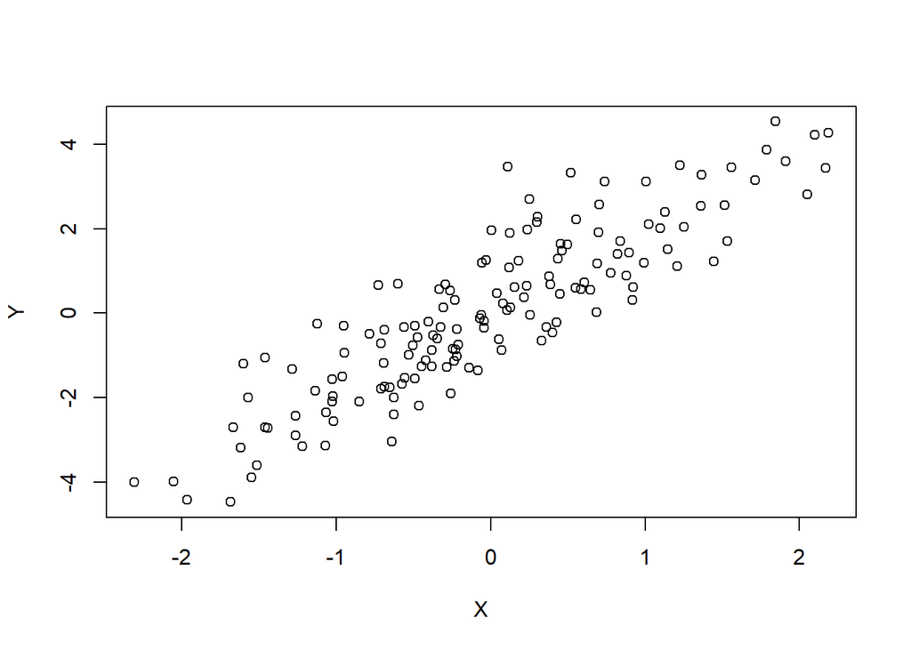

```r
plot(X,Y)
```

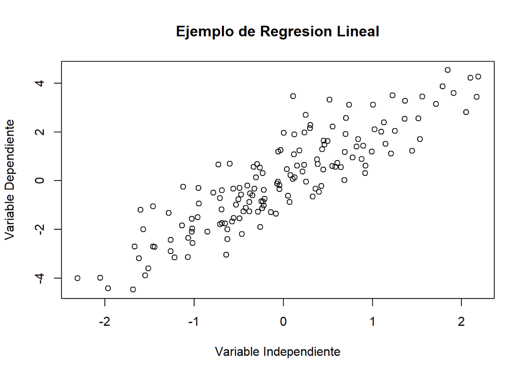

```r
plot(X,Y,main= 'Ejemplo de Regresion Lineal',
     xlab = 'Variable Independiente',
     ylab = 'Variable Dependiente')
```

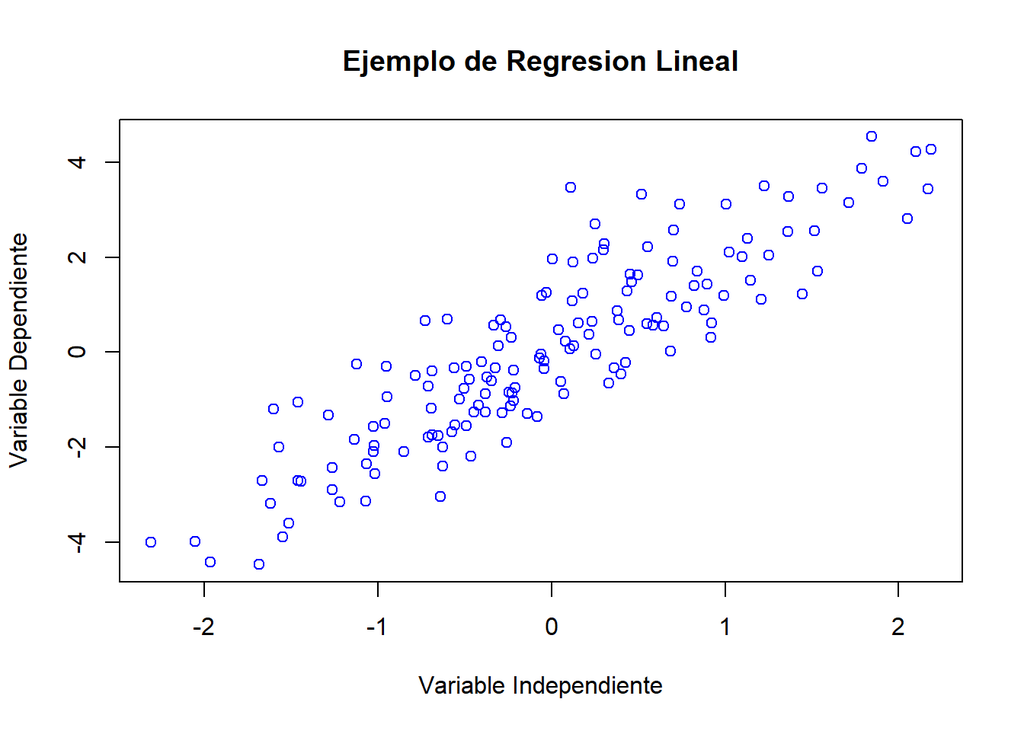

```r
plot(X,Y,main= 'Ejemplo de Regresion Lineal',
     xlab = 'Variable Independiente',
     ylab = 'Variable Dependiente',
     col = 'blue')
```

```r
# >>==<< >>==<< >>==<< >>==<< >>==<< >>==<< >>==<<
# >>==<< >>==<< >>==<< >>==<< >>==<< >>==<< >>==<<
set.seed(123)
numvar <- 150;
# >>==<< >>==<< >>==<< >>==<< >>==<< >>==<< >>==<<
# >>==<< >>==<< >>==<< >>==<< >>==<< >>==<< >>==<<
X1 <- rnorm(numvar);      print(X1)
```

```
##   [1] -0.560475647 -0.230177489  1.558708314  0.070508391  0.129287735
##   [6]  1.715064987  0.460916206 -1.265061235 -0.686852852 -0.445661970
##  [11]  1.224081797  0.359813827  0.400771451  0.110682716 -0.555841135
##  [16]  1.786913137  0.497850478 -1.966617157  0.701355902 -0.472791408
##  [21] -1.067823706 -0.217974915 -1.026004448 -0.728891229 -0.625039268
##  [26] -1.686693311  0.837787044  0.153373118 -1.138136937  1.253814921
##  [31]  0.426464221 -0.295071483  0.895125661  0.878133488  0.821581082
##  [36]  0.688640254  0.553917654 -0.061911711 -0.305962664 -0.380471001
##  [41] -0.694706979 -0.207917278 -1.265396352  2.168955965  1.207961998
##  [46] -1.123108583 -0.402884835 -0.466655354  0.779965118 -0.083369066
##  [51]  0.253318514 -0.028546755 -0.042870457  1.368602284 -0.225770986
##  [56]  1.516470604 -1.548752804  0.584613750  0.123854244  0.215941569
##  [61]  0.379639483 -0.502323453 -0.333207384 -1.018575383 -1.071791226
##  [66]  0.303528641  0.448209779  0.053004227  0.922267468  2.050084686
##  [71] -0.491031166 -2.309168876  1.005738524 -0.709200763 -0.688008616
##  [76]  1.025571370 -0.284773007 -1.220717712  0.181303480 -0.138891362
##  [81]  0.005764186  0.385280401 -0.370660032  0.644376549 -0.220486562
##  [86]  0.331781964  1.096839013  0.435181491 -0.325931586  1.148807618
##  [91]  0.993503856  0.548396960  0.238731735 -0.627906076  1.360652449
##  [96] -0.600259587  2.187332993  1.532610626 -0.235700359 -1.026420900
## [101] -0.710406564  0.256883709 -0.246691878 -0.347542599 -0.951618567
## [106] -0.045027725 -0.784904469 -1.667941937 -0.380226520  0.918996609
## [111] -0.575346963  0.607964322 -1.617882708 -0.055561966  0.519407204
## [116]  0.301153362  0.105676194 -0.640706008 -0.849704346 -1.024128791
## [121]  0.117646597 -0.947474614 -0.490557444 -0.256092192  1.843862005
## [126] -0.651949902  0.235386572  0.077960850 -0.961856634 -0.071308086
## [131]  1.444550858  0.451504053  0.041232922 -0.422496832 -2.053247222
## [136]  1.131337213 -1.460640071  0.739947511  1.909103569 -1.443893161
## [141]  0.701784335 -0.262197489 -1.572144159 -1.514667654 -1.601536174
## [146] -0.530906522 -1.461755585  0.687916773  2.100108941 -1.287030476
```

```r
Y1 <- X1+rnorm(numvar); print(Y1)
```

```
##   [1]  0.227263201  0.538864752  1.890910893 -0.937868217  0.009835129
##   [6]  1.434669652  1.023905739 -1.637499991  0.290120535 -0.820242828
##  [11]  2.276793263 -0.689363180 -0.859383794  3.351722651 -0.972698723
##  [16]  2.085140728  1.134420152 -2.450397782  1.218217946 -0.103826880
##  [21] -1.283204214 -0.152681881 -1.060071702  1.399560670 -1.366375364
##  [26] -2.782689578  0.875575444  0.463853867 -0.701613458  0.795449588
##  [31] -0.636861912  0.968113693  0.545475273  0.012620625  0.585301513
##  [36]  0.491464360  1.663837943  0.022825582  0.448091121 -0.879763018
##  [41] -0.480261669 -0.532603190 -1.170812823  1.273592607 -0.102839535
##  [46]  0.874104802  0.197823988 -1.717926715  0.168799202 -1.268849151
##  [51]  2.452128863  1.283866221 -0.308015514  1.911796343 -0.640110934
##  [56]  1.040223710 -2.337355642 -0.010003518  1.774761711  0.161913444
##  [61]  0.498884719 -0.258636024  0.899268495 -1.534639214 -2.064298377
##  [66]  1.979225574  0.007046562 -0.670061743 -0.314005651  0.765368963
##  [71] -1.065004645 -1.691183058  2.115586663 -0.001612409 -1.051665914
##  [76]  1.085321307 -0.989369471 -1.937935874  1.065953979 -1.154483941
##  [81]  1.961058151  0.294960807 -0.156121205 -0.094151156 -0.794875252
##  [86] -0.985234168  0.913913625  0.854163896 -0.001627241  0.367271131
##  [91]  0.204881885  0.046198241  1.734792405 -1.765209697  1.181600854
##  [96]  1.302102235  2.086358108  0.172769922 -0.900469794 -0.540960921
## [101] -1.086009435 -0.304992654 -0.590609113 -0.257045952  0.646890204
## [106] -0.133592837  0.295895027 -1.037187821 -0.493866416 -0.613905394
## [111] -1.096464280  0.118093869 -1.570728276  1.244636712  2.812486178
## [116]  1.848734421 -0.027474770 -2.397233404 -1.238484210 -0.934921568
## [121]  0.962659601  0.015053354  0.193751986 -1.651366542  2.693505051
## [126] -1.098507118  0.410189272  0.152512027 -0.533689869 -0.046633103
## [131] -0.222924239  1.188000018  0.427259490 -0.688148458 -1.935102710
## [136]  1.265375859 -1.239620602  2.380793677  1.690053190 -1.275827777
## [141]  1.870168208  0.791983534 -0.426881049 -2.092135655  0.400946557
## [146] -0.464205651  0.405096260 -0.662985913  2.121092527 -0.037115905
```

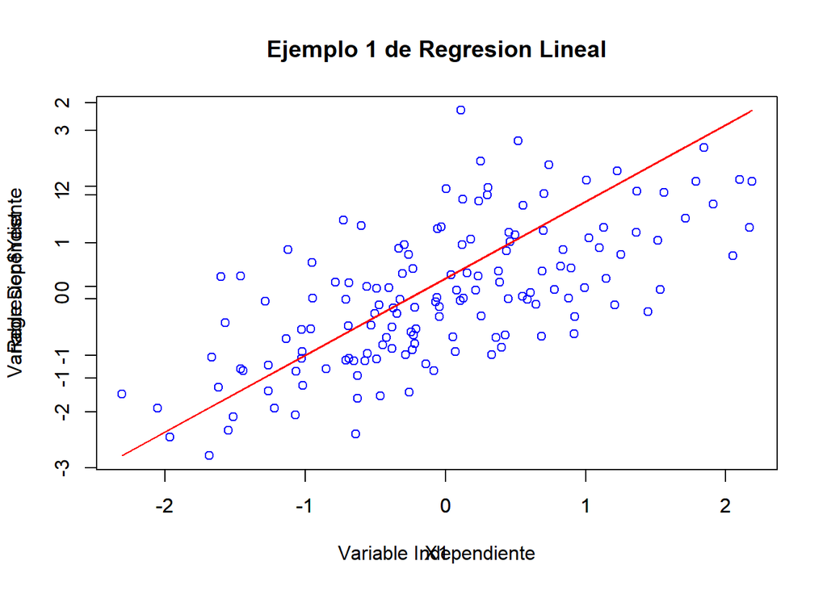

```r
Regresion <- MiRegresion(X1,Y1)
plot(X1,Y1,main= 'Ejemplo 1 de Regresion Lineal',
     xlab = 'Variable Independiente',
     ylab = 'Variable Dependiente',
     col = 'blue',
     type = 'p')
par(new=TRUE)
plot(X1,Regresion$Yest,col='red',type='l')
```

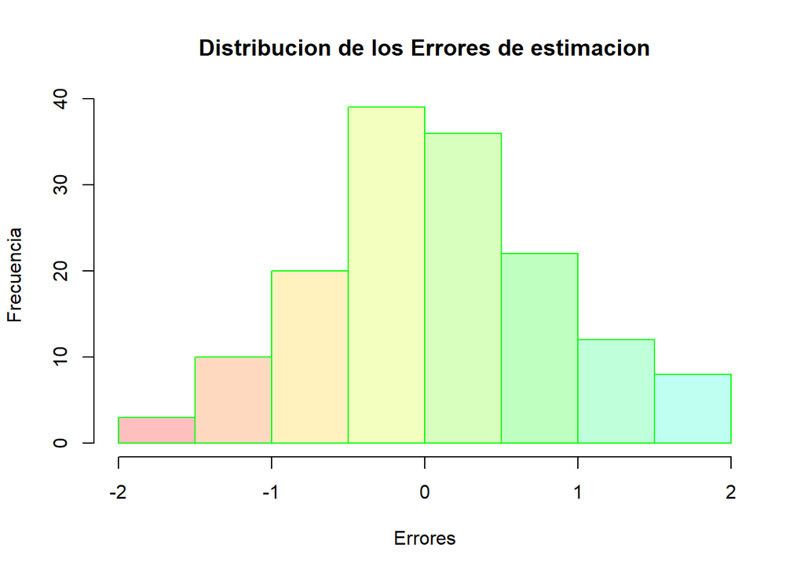

```r
Ygorro <- Regresion$Yest
hist(Ygorro, main='Distribucion de los Errores de estimacion',
     xlab='Errores',
     ylab= 'Frecuencia',
     col = rainbow(15, 0.25),
     border = 'green')
```

```r
# >>==<< >>==<< >>==<< >>==<< >>==<< >>==<< >>==<<
# >>==<< >>==<< >>==<< >>==<< >>==<< >>==<< >>==<<
X2 <- rnorm(numvar);      print(X2)
```

```
##   [1] -0.71524219 -0.75268897 -0.93853870 -1.05251328 -0.43715953  0.33117917
##   [7] -2.01421050  0.21198043  1.23667505  2.03757402  1.30117599  0.75677476
##  [13] -1.72673040 -0.60150671 -0.35204646  0.70352390 -0.10567133 -1.25864863
##  [19]  1.68443571  0.91139129  0.23743027  1.21810861 -1.33877429  0.66082030
##  [25] -0.52291238  0.68374552 -0.06082195  0.63296071  1.33551762  0.00729009
##  [31]  1.01755864 -1.18843404 -0.72160444  1.51921771  0.37738797 -2.05222282
##  [37] -1.36403745 -0.20078102  0.86577940 -0.10188326  0.62418747  0.95900538
##  [43]  1.67105483  0.05601673 -0.05198191 -1.75323736  0.09932759 -0.57185006
##  [49] -0.97400958 -0.17990623  1.01494317 -1.99274849 -0.42727929  0.11663728
##  [55] -0.89320757  0.33390294  0.41142992 -0.03303616 -2.46589819  2.57145815
##  [61] -0.20529926  0.65119328  0.27376649  1.02467323  0.81765945 -0.20979317
##  [67]  0.37816777 -0.94540883  0.85692301 -0.46103834  2.41677335 -1.65104890
##  [73] -0.46398724  0.82537986  0.51013255 -0.58948104 -0.99678074  0.14447570
##  [79] -0.01430741 -1.79028124  0.03455107  0.19023032  0.17472640 -1.05501704
##  [85]  0.47613328  1.37857014  0.45623640 -1.13558847 -0.43564547  0.34610362
##  [91] -0.64704563 -2.15764634  0.88425082 -0.82947761 -0.57356027  1.50390061
##  [97] -0.77414493  0.84573154 -1.26068288 -0.35454240 -0.07355602 -1.16865142
## [103] -0.63474826 -0.02884155  0.67069597 -1.65054654 -0.34975424  0.75640644
## [109] -0.53880916  0.22729192  0.49222857  0.26783502  0.65325768 -0.12270866
## [115] -0.41367651 -2.64314895 -0.09294102  0.43028470  0.53539884 -0.55527835
## [121]  1.77950291  0.28642442  0.12631586  1.27226678 -0.71846622 -0.45033862
## [127]  2.39745248  0.01112919  1.63356842 -1.43850664 -0.19051680  0.37842390
## [133]  0.30003855 -1.00563626  0.01925927 -1.07742065  0.71270333  1.08477509
## [139] -2.22498770  1.23569346 -1.24104450  0.45476927  0.65990264 -0.19988983
## [145] -0.64511396  0.16532102  0.43881870  0.88330282 -2.05233698 -1.63637927
```

```r
Y2 <- 9*X2 +rnorm(numvar); print(Y2)
```

```
##   [1]  -5.006777344  -5.727571867  -8.011559384  -8.757441107  -3.017260881
##   [6]   0.319689758 -17.017617385   1.422836304  11.360692248  18.043008363
##  [11]  12.582548884   6.462500425 -15.022069826  -5.804245351  -4.261205318
##  [16]   7.541725635  -0.210141995  -9.603575413  15.225075305   9.327524372
##  [21]   4.112291506  10.681495378 -13.371919698   5.708031113  -4.920252627
##  [26]   6.305390201   1.164907385   5.370502525  12.392663191  -0.162073252
##  [31]   9.178478441 -10.381848653  -5.166225268  13.794277780   4.109334077
##  [36] -17.691145354 -11.361563798  -2.381423692   9.418895853  -1.297906041
##  [41]   5.511903081  10.035098668  16.333577366  -0.585841273  -1.340908156
##  [46] -17.137215292   1.075795539  -4.981809653  -8.401971558  -1.066998365
##  [51]   8.532595709 -18.928434989  -2.818728529   1.800796855  -9.548034668
##  [56]   2.909979032   2.806921463  -2.368076504 -22.042963613  23.063911604
##  [61]  -1.945062585   6.076892076   3.346363584   9.427656618   6.742499174
##  [66]  -2.622937793   3.271707157  -8.198662494   6.672626745  -4.333653919
##  [71]  22.718227444 -14.967720152  -4.874305854   7.152473596   5.705841467
##  [76]  -4.755285385  -7.734350880   1.439379200   0.281508378 -16.670988048
##  [81]   0.916330273   1.205739299   0.151972068  -9.367160418   6.231050722
##  [86]  13.208045572   5.271381019  -9.861440510  -4.529366406   2.912691721
##  [91]  -6.096658789 -19.887516795   8.662424664  -8.662662007  -4.295676305
##  [96]  14.399257967  -8.165926726   8.251075860  -8.915919257  -3.748097110
## [101]   0.182900069 -11.300064665  -4.602022966  -0.009749256   7.688179110
## [106] -16.313889619  -3.199086039   6.280732771  -5.046547309   1.416048552
## [111]   3.596213550   2.989237513   4.791738401   0.379652983  -4.909295208
## [116] -23.687261417  -0.303479879   4.459297606   4.516842904  -4.918003166
## [121]  16.976790340   1.121353860   0.355103015  11.770803330  -6.910977970
## [126]  -2.683043621  22.250326184   0.172329437  13.194358475 -12.920459579
## [131]  -2.031067087   3.303468619   1.518787680  -8.552068292  -0.865622969
## [136]  -9.923007859   6.795755757   8.979460020 -19.441897863   9.804730759
## [141] -13.979175150   4.557891412   6.779663570  -2.084853877  -5.301899357
## [146]   0.331972666   3.822219700   6.008207003 -17.289851964 -12.867502551
```

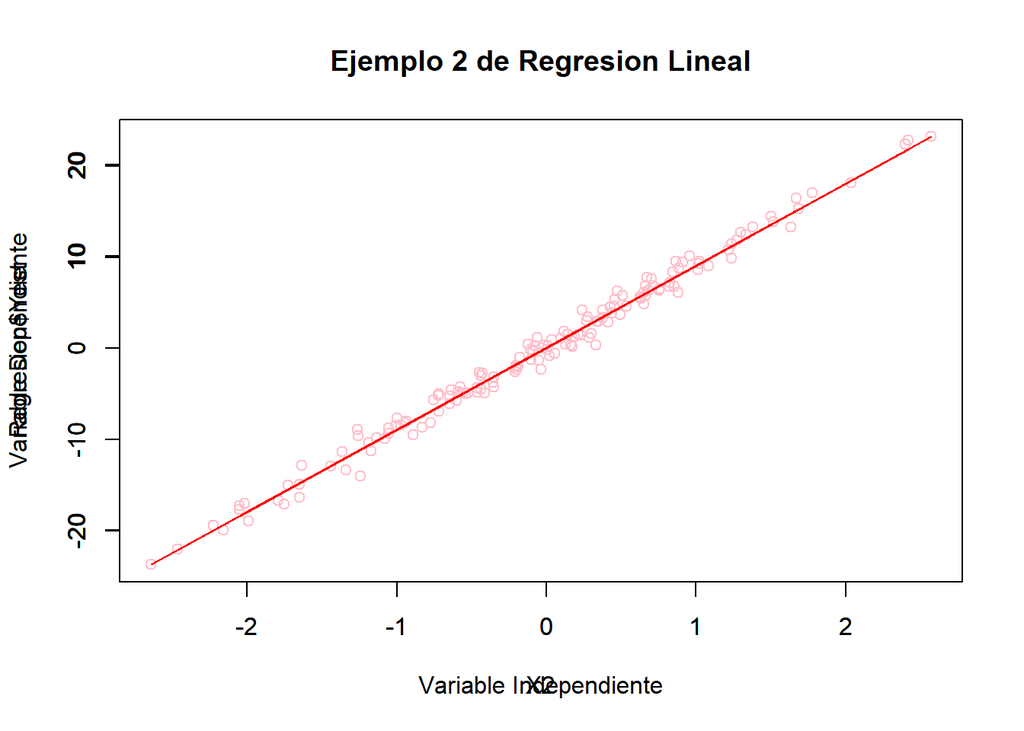

```r
Regresion <- MiRegresion(X2,Y2)
plot(X2,Y2,main= 'Ejemplo 2 de Regresion Lineal',
     xlab = 'Variable Independiente',
     ylab = 'Variable Dependiente',
     col = 'pink',
     type = 'p')
par(new=TRUE)
plot(X2,Regresion$Yest,col='red',type='l')
```

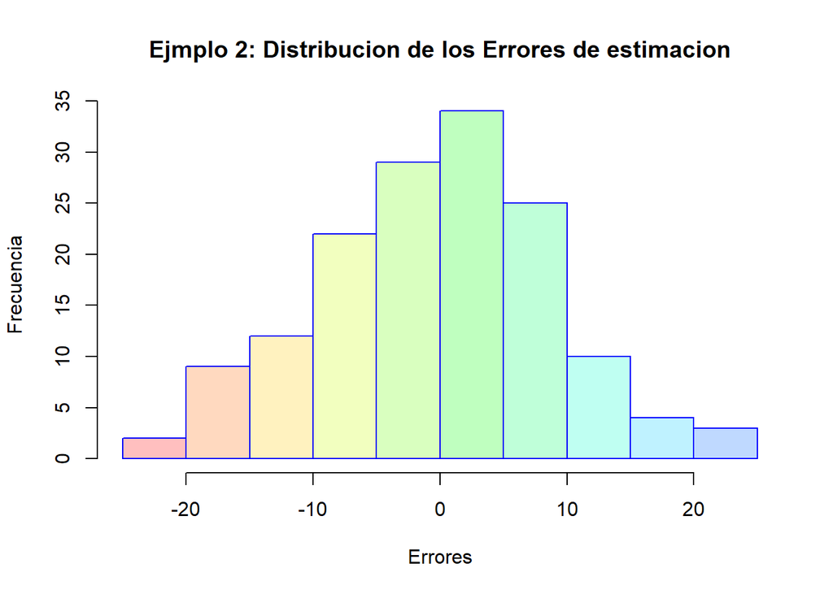

```r
Ygorro <- Regresion$Yest
hist(Ygorro, main='Ejmplo 2: Distribucion de los Errores de estimacion',
     xlab='Errores',
     ylab= 'Frecuencia',
     col = rainbow(15, 0.25),
     border = 'blue')
```

```r
# >>==<< >>==<< >>==<< >>==<< >>==<< >>==<< >>==<<
X3 <- rnorm(numvar);      print(X3)
```

```
##   [1]  1.074012260 -0.027346966 -0.033330342 -1.516067623  0.790385344
##   [6] -0.210734181 -0.656742925 -1.412025793 -0.299762497 -0.849061135
##  [11] -0.397030520 -1.217599988  1.687589483 -0.016002527  1.074945077
##  [16] -2.601699670 -0.453197830 -0.675482292 -1.222926179  1.546609154
##  [21] -1.415281920  0.318390260  0.846436286  0.178190188 -0.875255477
##  [26]  0.941165807  0.170588082 -1.063497906 -1.388049048  2.086717434
##  [31] -0.678503145 -1.855571654  0.533259363  0.310230256 -1.353834336
##  [36] -1.942956414 -0.116302517  1.139396292  0.636124035 -0.492937424
##  [41] -0.834188232  0.271066757  0.157353347  0.629711747 -0.395797950
##  [46]  0.899354053 -0.830811527 -0.330544700  0.740814524  0.989971609
##  [51] -1.938504701  0.107190407  0.608779012 -1.450824313  0.480625600
##  [56] -0.828174270  1.020253012  0.538482032  0.769052295  0.120719329
##  [61]  0.863648434  1.380514528  1.966248015 -0.028395055 -2.249051090
##  [66]  0.031526005  0.205561208 -0.155345347  0.568288621  1.010677965
##  [71] -0.517982430 -0.294095327  0.397842209 -0.550223741  0.091267383
##  [76] -1.961707599 -1.119899721 -1.327755476 -0.853623697 -0.693304528
##  [81]  0.382305143  0.982113003 -0.727383529 -0.996838982 -1.041688859
##  [86] -0.414588726 -0.239029068  0.483617534 -0.321324842 -2.078489269
##  [91] -0.091434276  1.187186811  1.191601269 -0.788963218 -1.547776544
##  [96]  2.458060492 -0.162421942 -0.097451250  0.420574189 -1.614039457
## [101] -0.728219111 -1.540442405 -0.693094614  0.118849433 -1.364709458
## [106]  0.589982679  0.289344029 -0.904215026  0.226324942  0.748081162
## [111]  1.061095253 -0.212848279 -0.093636794 -0.086714135  1.441461756
## [116]  1.125071892  0.834401568 -0.287340800  0.373241434  0.403290331
## [121] -1.041673294 -1.728304515  0.641830028 -1.529310531  0.001683688
## [126]  0.250247821  0.563867390  0.189426238 -0.732853806  0.986365860
## [131]  1.738633767  0.881178809 -1.943650901  1.399576185 -0.056055946
## [136]  0.524914279  0.622033236 -0.096686073 -0.075263198  1.019157069
## [141]  0.711601922  0.990262246  2.382926695  0.664415864  0.207381157
## [146] -2.210633111  2.691714003 -0.482676822  2.374734715  0.374643568
```

```r
Y3 <- -2*X3 +rnorm(numvar); print(Y3)
```

```
##   [1] -0.609594322 -0.055016388  0.578131439  3.246093226 -1.766891387
##   [6]  0.301074537  2.326320187  2.622593438 -1.438157501  1.502233021
##  [11]  1.333851646  3.051655692 -2.758611148 -1.660096466 -1.781148097
##  [16]  6.171258550  2.182974341  1.126003312  2.123959773 -1.605380477
##  [21]  1.162635794 -1.073610498 -1.235410492 -1.974154142  2.030138817
##  [26] -0.004467592 -0.345236817  1.848541788  3.251009809 -4.452507040
##  [31]  2.170406665  4.615578772 -1.063827064 -1.797152670  1.389447944
##  [36]  3.292915462  1.029985535 -4.236997758 -3.158573229  0.332095024
##  [41]  2.062771311 -1.455699562  0.572042343 -0.926053523  0.620956282
##  [46] -0.979879970  2.049988217  0.215154373 -1.250514113 -1.332429859
##  [51]  4.233292748 -0.872391022 -0.362355818  4.054584853 -0.684976643
##  [56]  1.800453203 -2.116131105  1.084451782 -1.261789058 -0.399732687
##  [61] -4.235214671 -4.326310822 -4.010169232  0.263084154  4.774974640
##  [66]  0.758454771 -0.605274826  1.525279489 -2.058093284 -3.229798649
##  [71] -0.193021317  1.330487678 -0.878604360  1.890265405 -0.450241189
##  [76]  3.331523096  1.871446868  0.802894127  0.537632133 -0.055425590
##  [81]  0.289711987 -2.561556096  2.244226911  3.510168566  1.891602909
##  [86]  1.113056359 -1.273009383 -1.785904845  0.698864534  4.456065441
##  [91] -0.576529566  0.310485378 -2.841592676  1.642169993  3.745344954
##  [96] -4.942139619 -0.318723502  1.240208164  0.774396946  3.198384942
## [101]  2.018705568  2.983472312  2.402644446 -1.393866260  5.050279140
## [106] -1.783496607 -2.037537472  1.457512224 -0.305941401  0.127458883
## [111] -1.210980830  0.568154989 -1.202209936 -0.692609475 -3.046208444
## [116]  0.302882329 -3.529030710  1.705736252 -1.273717126  0.859410238
## [121]  0.944145949  3.600232265 -2.383210997  3.962137489  1.480412112
## [126]  1.450225364 -0.330134123  1.464413780  2.712131521 -2.104606632
## [131] -3.000230296 -2.734351829  3.702099633 -1.578188662  0.653396036
## [136] -0.592471227 -2.282197511 -0.411141084 -0.614079618 -1.643018269
## [141] -2.413711475 -1.418483102 -5.882269802  0.499698731  0.045829035
## [146]  3.720262609 -5.142382074  0.612900444 -4.378321470 -0.505754417
```

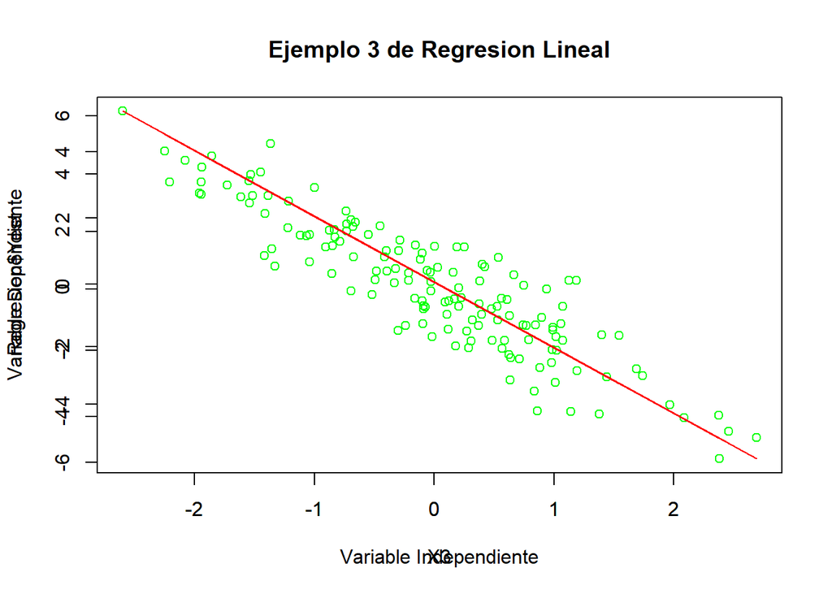

```r
Regresion <- MiRegresion(X3,Y3)
plot(X3,Y3,main= 'Ejemplo 3 de Regresion Lineal',
     xlab = 'Variable Independiente',
     ylab = 'Variable Dependiente',
     col = 'green',
     type = 'p')
par(new=TRUE)
plot(X3,Regresion$Yest,col='red',type='l')
```

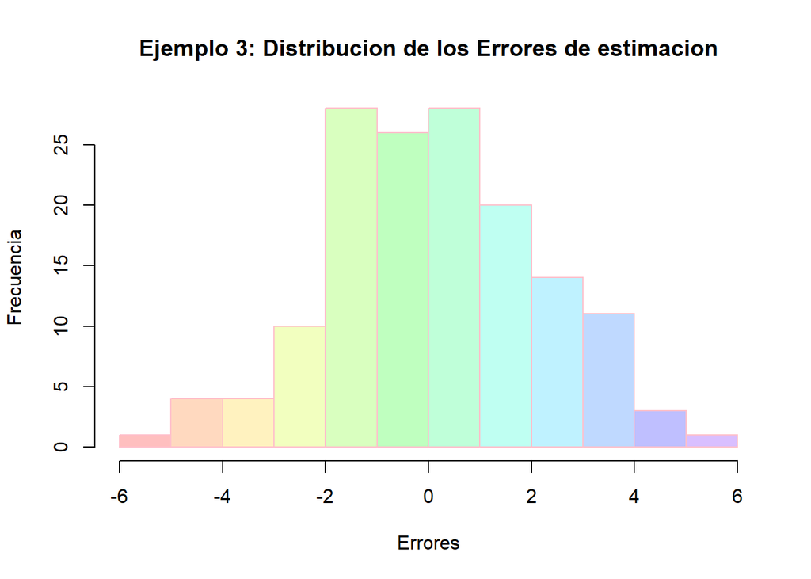

```r
Ygorro <- Regresion$Yest
hist(Ygorro, main='Ejemplo 3: Distribucion de los Errores de estimacion',
     xlab='Errores',
     ylab= 'Frecuencia',
     col = rainbow(15, 0.25),
     border = 'pink')
```

```r
# >>==<< >>==<< >>==<< >>==<< >>==<< >>==<< >>==<<
X4 <- rnorm(numvar);      print(X4)
```

```
##   [1] -1.014114173 -0.791313879  0.299593685  1.639051909  1.084617009
##   [6] -0.624567474  0.825922902 -0.048568353  0.301313652  0.260361491
##  [11]  2.575449764 -1.185288811  0.100919859 -1.779977288  0.589835923
##  [16]  1.096608472  1.445662241 -1.925145252  0.412769497  1.593369951
##  [21] -0.414015863 -0.212150532 -0.036537222  0.365018751  0.665159876
##  [26]  1.317820884 -0.095487590  0.196278045  2.487997877  0.431098928
##  [31]  0.188753109 -1.342243125  0.002856048 -0.221326153 -0.011045830
##  [36] -0.575417641 -0.686815652 -0.720773632 -0.214504515  1.368132648
##  [41]  1.049086627 -0.359975118 -1.685916455 -0.844583429 -0.457760533
##  [46]  0.103638004 -0.662607276  2.006680691 -0.272267534 -1.213944470
##  [51] -0.141261757 -1.005377582  0.156155707  0.233633614  0.355587612
##  [56] -1.621858259  0.220711291  0.310450081 -1.421108448  0.955365640
##  [61]  0.784170879  2.299619361  0.156702987  0.046733528  0.096585834
##  [66]  0.069766231 -1.848472775 -1.671127059 -0.077538967 -0.581067381
##  [71]  0.054736525 -2.111208373 -1.498698255 -1.101483439  0.986058221
##  [76] -1.098490007 -0.799513954  0.079873819 -0.322746362  0.146417179
##  [81]  2.305061982 -1.124603671 -0.305469640 -0.516759450  1.512395427
##  [86] -0.769484923 -0.082086904  0.787133614 -1.058590536  1.655175816
##  [91]  0.675762415 -1.074206610  0.454577809 -0.213307143  0.313228772
##  [96] -0.089975197  1.070516037 -1.351100386 -0.522616697 -0.249190678
## [101] -0.995798725 -1.039955044 -0.017980241 -0.132175133 -2.549342775
## [106]  1.040573456  0.249725736  2.416207373  0.685198238 -0.446959309
## [111]  2.797391147  2.832226024 -1.218711816  0.469031956 -0.211246919
## [116]  0.187051147  0.227542729 -1.261900463  0.285589580  1.749247363
## [121] -0.164090004 -0.162926711  1.398572006  0.898396241 -1.648494818
## [126]  0.228556973  1.653547235  1.415276350  0.419951604  0.721220807
## [131] -1.196935212  0.300131567 -0.954448935 -0.458018068  0.935603684
## [136] -1.136893112  0.266918251  0.428332039  0.054911970  1.822188822
## [141] -1.022347329  0.606130261 -0.088930567 -0.260832244  0.464091234
## [146] -1.020400591 -1.313450917 -0.494480875  1.751757150  0.055764775
```

```r
Y4 <- -2*X4 - rnorm(numvar); print(Y4)
```

```
##   [1]  1.69679395  1.77247440 -1.06968010 -2.32642427 -3.32714448  0.66442969
##   [7] -0.84539298  0.04258346 -1.31895892 -1.07845396 -6.63283354  2.98356538
##  [13] -1.31797633  2.52340657 -1.01718871 -1.21729025 -1.80217929  3.39250355
##  [19] -0.75441226 -4.96584257  0.29289377  0.79624594  1.09861669 -0.14763583
##  [25] -1.67320814 -2.18470712 -0.32325494 -0.05821804 -4.87043585 -0.13168818
##  [31] -2.28254980  2.35186452 -0.23634574  2.13451472 -0.63770024  2.17445887
##  [37]  2.26515288  0.52320609  0.88170968 -0.98789302 -3.86807736  3.09735716
##  [43]  2.79902138  0.67191761  1.54648893 -0.65156306  0.88608416 -5.05398453
##  [49]  0.06043568  2.67277272 -0.63346854  1.21013281  0.62425762  0.93352021
##  [55] -0.87145276  3.51767889  0.54411653 -0.70483084  4.16221342 -2.07195763
##  [61] -0.94341337 -5.55640300 -2.73789512  0.82251219 -1.25083584 -0.96468219
##  [67]  3.76713977  3.79590049 -1.42022977  3.16759258  0.53372174  5.65926019
##  [73]  1.60208307  2.39367031 -1.44744524 -0.98706446  1.64906518  0.28400167
##  [79]  0.34562747  1.27559026 -5.10042661  2.34537054  0.14241416  2.01588954
##  [85] -2.00180701  2.23238451  0.93216338 -2.87331720  0.53803551 -3.15345968
##  [91] -0.99258827  2.47745205 -0.97839210  0.32971005 -0.91649193  0.92662934
##  [97] -1.29413568  1.50512311  1.59386076  0.19533566  2.04856798  3.03775948
## [103] -0.55510143  0.09124539  3.69890219 -2.19860650 -0.16790571 -5.11070966
## [109] -0.18480483  1.72981267 -6.10505555 -5.33133115  2.50338458 -0.82284220
## [115]  1.07300646  1.64458637 -0.80392043  1.76216142  0.71753707 -4.98089744
## [121] -0.05697482 -1.01578687 -1.83997354 -1.96357377  3.39700360 -1.22562138
## [127] -2.73123490 -2.82045503  0.93875594 -0.66482017  2.26883654  0.10605836
## [133]  1.95246736  1.38396211 -2.47813750  1.10529791  0.28866491 -0.54962752
## [139] -1.54958520 -1.44545439  2.36453245 -3.27696481 -2.01572893  0.36506916
## [145] -0.06457352  1.87534376  3.27967623 -0.46385553 -2.69703164 -0.48444114
```

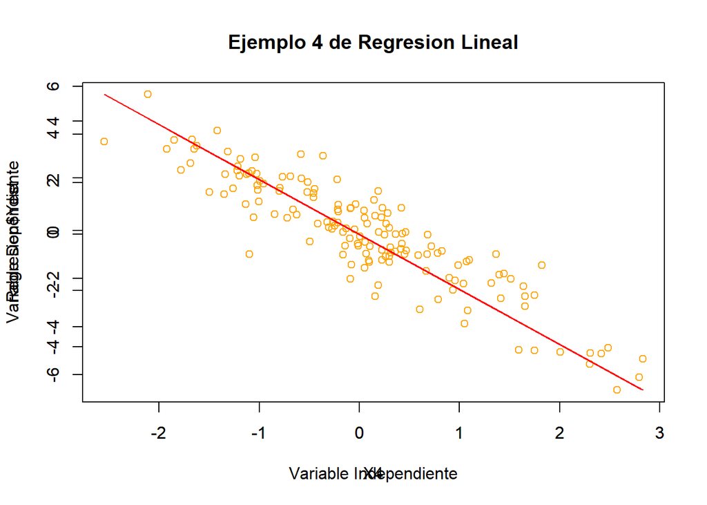

```r
Regresion <- MiRegresion(X4,Y4)
plot(X4,Y4,main= 'Ejemplo 4 de Regresion Lineal',
     xlab = 'Variable Independiente',
     ylab = 'Variable Dependiente',
     col = 'orange',
     type = 'p')
par(new=TRUE)
plot(X4,Regresion$Yest,col='red',type='l')
```

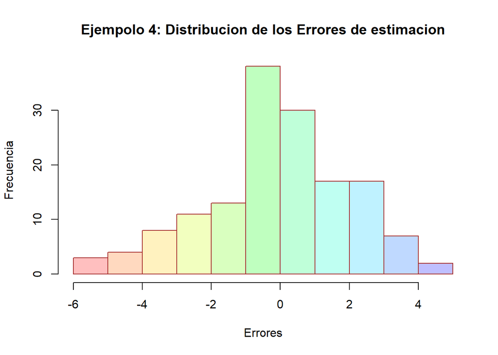

```r
Ygorro <- Regresion$Yest
hist(Ygorro, main='Ejempolo 4: Distribucion de los Errores de estimacion',
     xlab='Errores',
     ylab= 'Frecuencia',
     col = rainbow(15, 0.25),
     border = 'brown')
```

```r
# >>==<< >>==<< >>==<< >>==<< >>==<< >>==<< >>==<<
X5 <- rnorm(numvar);      print(X5)
```

```
##   [1]  0.6198500746 -0.7575101607  0.8515246815 -0.7479299709  0.6302398297
##   [6]  1.0966616331 -0.9884429224  1.1079950410 -0.4895328712  0.2943533884
##  [11]  0.2018374723 -0.4271963863  0.2681028700 -1.2304309254 -0.1361368722
##  [16]  0.8257908317 -2.1741246492 -1.4879261874 -1.1619375576 -1.5890896941
##  [21]  0.4195830393 -0.9929283498 -2.1645470853 -0.6375687651 -0.3906352515
##  [26]  0.8567854738 -1.1037521360  1.1612892557  0.3983627156  0.3623521576
##  [31] -0.8525256703  1.9536678799 -0.1642708321 -1.8248975842 -0.2038564714
##  [36] -1.9344440707 -0.3105101158 -0.4222270032  0.6818296904  1.0094961857
##  [41] -0.7261049649  0.8061088684  1.4243231097 -0.7841440048 -0.6524043665
##  [46]  0.6507783632  0.1830479699  0.5487749604  1.4046842945  0.3870831196
##  [51]  1.0517012702  0.6229054623  0.4336203898  0.3860844382  1.2913233045
##  [56] -1.0022598737 -1.1051827292  0.5919460034 -0.1196896641  0.0740052117
##  [61]  0.7412773772  0.7532950478 -0.2626705034 -0.3125438690  0.0735986090
##  [66]  1.0630177893  0.4260204867  1.4330075108 -0.0076368704  1.1256676052
##  [71]  0.8830023110  0.6120834609  0.4147007068 -0.2798823971 -0.1090375092
##  [76]  0.2293954957  0.0488888907  0.9432244684 -0.1093171232 -0.0703769216
##  [81] -0.4843190876 -0.1383363285 -0.0687656423 -2.3137357739 -1.3648316972
##  [86] -0.0724869100 -0.2652837749 -1.2008693282 -1.9915381760 -0.3543692199
##  [91]  0.6534957657  1.7732386319 -0.0384567937  1.4931848406  0.0830221576
##  [96]  0.1155321043  0.3248253133 -0.8705772453 -0.0517182129  0.9084476988
## [101] -0.7497257869 -0.3216060699 -1.1477707505  0.3543521964  0.4247997824
## [106]  0.6483473512 -1.2198100315  0.1072350348 -0.9440576916 -0.0003846487
## [111]  1.3426239200 -0.5035252869  0.7166833209 -0.7496685841 -0.4785282105
## [116]  0.4387217506 -0.6791122705 -1.7029648351  1.2651684352  0.3603572379
## [121] -0.5836394406 -1.9940787873  1.9022097714  3.3903708213  0.2074804074
## [126]  0.8498066475  1.2245603121 -0.7018044335 -0.3511962296 -1.7271210366
## [131] -0.7365782323  0.6224097829 -0.2907159892 -0.2142115342 -0.1125595515
## [136] -1.8636669825  0.8376299342 -1.4434928889 -0.2085701624 -0.4385634621
## [141] -0.2185938169  1.4599659447 -0.5820599179 -0.7830975957 -1.5196539949
## [146] -0.8056980816 -1.1661847074  0.4079461962 -0.8630042460  0.3040420350
```

```r
Y5 <- -2*X5 - 2*rnorm(numvar); print(Y5)
```

```
##   [1] -0.94684517  4.38214468 -0.12183379 -0.27436497 -3.06663183 -6.20446981
##   [7]  1.98404646  0.77566355  2.51589980 -1.40568379 -4.20394761  0.63437453
##  [13] -2.81697939  0.92469924  2.60845699 -1.30935636  1.73772623  1.22366016
##  [19]  1.39628283  2.22395090  0.14364452  4.62462733  1.73824259  4.11557651
##  [25]  2.65906234 -2.97150093  4.73189337 -1.21883768  1.56887358 -1.96603143
##  [31]  0.81242531 -4.75110515 -0.55638788  2.53530368 -0.87100004  7.80621125
##  [37]  0.91865295  0.61952638 -2.81301179  0.35597978  2.45141031  0.53506824
##  [43] -4.96312664 -0.98985716 -0.27054472  1.14325004 -1.27000017 -3.39844829
##  [49] -3.14525055  0.35805243  0.06883394  0.08479467 -2.29693749  0.09115332
##  [55] -3.03787649 -0.58537184  1.05369558 -3.91323757  3.64253893  0.41334214
##  [61] -1.61269079 -2.66376868  2.86375425 -0.98728197 -0.76197737 -2.65364761
##  [67] -1.86901056 -2.63329814 -1.83581846 -3.54779476 -1.46558587 -3.30492096
##  [73] -1.41451878 -0.77773800  1.40643030 -3.61965467 -0.08979989 -3.58213447
##  [79]  0.41886730  0.70001366 -0.60023832  3.44590595 -0.81920101  3.84033880
##  [85]  8.12032213 -0.59178084  4.86740304  1.08212990  4.89090382  2.09861209
##  [91] -1.29329893 -6.29258135  1.34755974 -4.10257627 -0.84836005  2.12797305
##  [97]  2.83239341  5.72632603 -0.99911200 -1.74741127 -2.20169183 -0.50413808
## [103]  0.59614972 -3.37747156  0.15183863 -2.31689056  0.70203352 -2.95317345
## [109]  0.36281309 -0.84152505 -0.94879975 -0.45207015 -2.43389839  0.23083666
## [115]  0.10976633 -0.47376741  1.51195634  2.03120144 -2.87359988  0.93950267
## [121]  1.74759712  6.62640902 -1.87035574 -6.49151950  3.18130430  1.67747165
## [127] -4.65425102  2.55684672  4.40577592  3.67996855 -1.16898207 -2.56932816
## [133] -0.30133442 -1.93906876  1.76812199  2.26795558 -0.50108864  2.88545741
## [139] -4.01179031 -1.06174187 -1.09882779 -0.70327607  2.73659168 -3.00203777
## [145]  5.22590952  1.18243741  0.54722730 -2.85340834 -0.45221553 -0.28182609
```

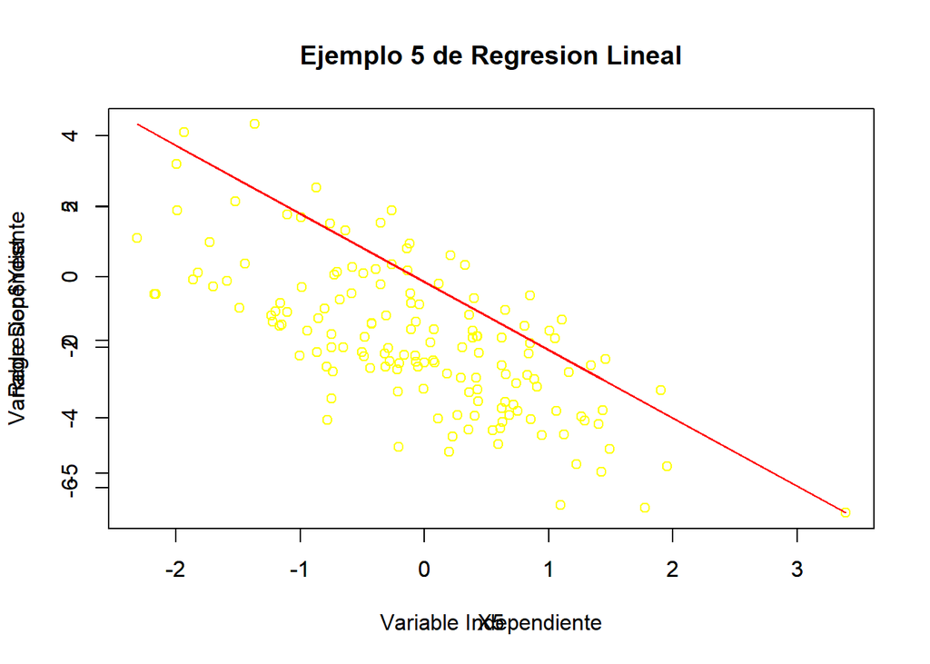

```r
Regresion <- MiRegresion(X5,Y5)
plot(X5,Y5,main= 'Ejemplo 5 de Regresion Lineal',
     xlab = 'Variable Independiente',
     ylab = 'Variable Dependiente',
     col = 'yellow',
     type = 'p')
par(new=TRUE)
plot(X5,Regresion$Yest,col='red',type='l')
```

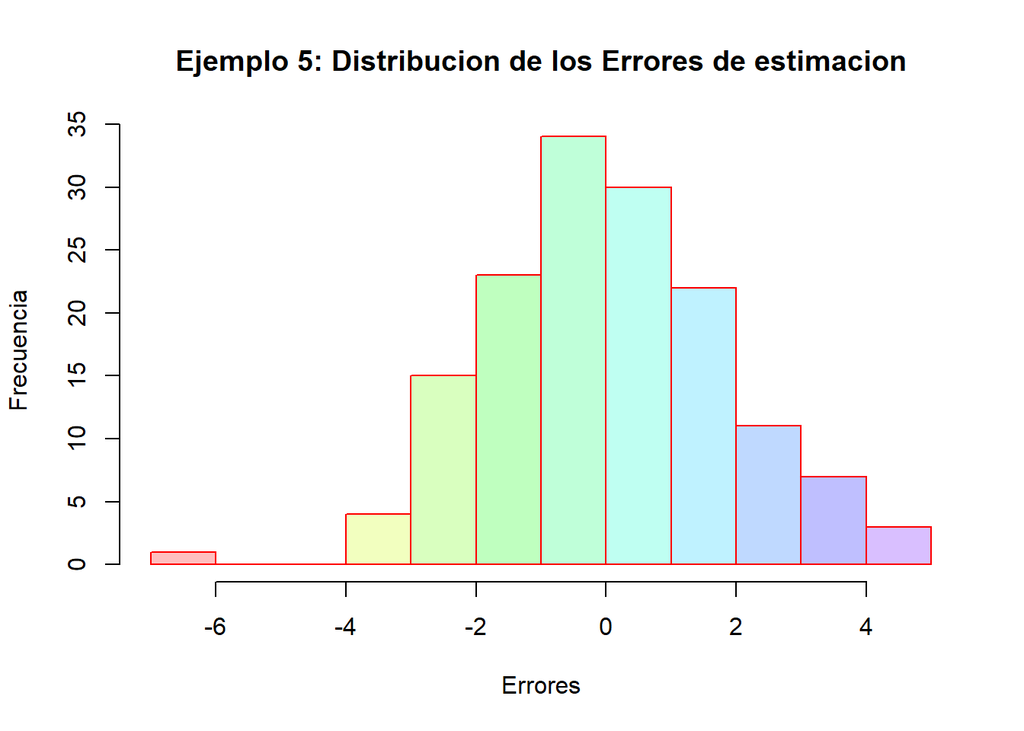

```r
Ygorro <- Regresion$Yest
hist(Ygorro, main='Ejemplo 5: Distribucion de los Errores de estimacion',
     xlab='Errores',
     ylab= 'Frecuencia',
     col = rainbow(15, 0.25),
     border = 'red')
```

```r
# >>==<< >>==<< >>==<< >>==<< >>==<< >>==<< >>==<<
suma <- 0;
for(i in 1:numvar){suma <- suma +X[i]}
xbarra <- suma/numvar;

suma <- 0;
for(i in 1:numvar){suma <- suma +Y[i]}
ybarra <- suma/numvar;

suma <- 0;
for(i in 1:numvar){suma <- suma +(X[i]-xbarra)^2}
Sxx <- suma/numvar

suma <- 0;
for(i in 1:numvar){suma <- suma+((X[i]-xbarra)*(Y[i]-ybarra))}
Sxy <- suma/numvar;

Beta1 <- Sxy/Sxx;
Beta0 <- ybarra-Beta1*xbarra

Ygorro <- Beta0+Beta1*X; print(Ygorro)
```

```
##   [1] -0.940252192 -0.333535776  2.952423769  0.218786590  0.326756895
##   [6]  3.239631427  0.935916930 -2.234487818 -1.172391316 -0.729353824
##  [11]  2.337756699  0.750204502  0.825438535  0.292581801 -0.931739173
##  [16]  3.371607495  1.003760570 -3.523158327  1.377574588 -0.779187209
##  [21] -1.872187140 -0.311121172 -1.795370392 -1.249610559 -1.058847491
##  [26] -3.008973223  1.628181538  0.370998732 -2.001343754  2.392372729
##  [31]  0.872632943 -0.452737928  1.733505407  1.702292909  1.598413211
##  [36]  1.354217533  1.106748961 -0.024452580 -0.472743666 -0.609606165
##  [41] -1.186818365 -0.292646551 -2.235103386  4.073372401  2.308146643
##  [46] -1.973738547 -0.650777576 -0.767916044  1.521969890 -0.063867060
##  [51]  0.554585928  0.036834671  0.010523822  2.603222762 -0.325441580
##  [56]  2.874838378 -2.755593760  1.163133851  0.316776251  0.485929153
##  [61]  0.786621752 -0.833433883 -0.522788809 -1.781724129 -1.879474979
##  [66]  0.646815654  0.912576812  0.186633628  1.783361513  3.855020724
##  [71] -0.812691364 -4.152383003  1.936687407 -1.213441634 -1.174514311
##  [76]  1.973117864 -0.433820916 -2.153034312  0.422303314 -0.165854575
##  [81]  0.099859580  0.796983414 -0.591584641  1.272910641 -0.315734754
##  [86]  0.698713474  2.104027614  0.888645477 -0.509424078  2.199487444
##  [91]  1.914213851  1.096608136  0.527791839 -1.064113459  2.588619908
##  [96] -1.013330316  4.107128704  2.904485580 -0.343680597 -1.796135363
## [101] -1.215656540  0.561134745 -0.363870644 -0.549120808 -1.658732830
## [106]  0.006561191 -1.352499878 -2.974529293 -0.609157084  1.777353354
## [111] -0.967568940  1.206025934 -2.882576750 -0.012788892  1.043357580
## [116]  0.642452563  0.283385447 -1.087625334 -1.471529148 -1.791925044
## [121]  0.305373580 -1.651120906 -0.811821195 -0.381137845  3.476215445
## [126] -1.108278961  0.521647193  0.232475824 -1.677538879 -0.041712547
## [131]  2.742730797  0.918627982  0.165011213 -0.686802362 -3.682286924
## [136]  2.167396494 -2.593741686  1.448462549  3.596056041 -2.562979706
## [141]  1.378361567 -0.392352512 -2.798560754 -2.692983600 -2.852550209
## [146] -0.885937407 -2.595790746  1.352888589  3.946909025 -2.274842568
```

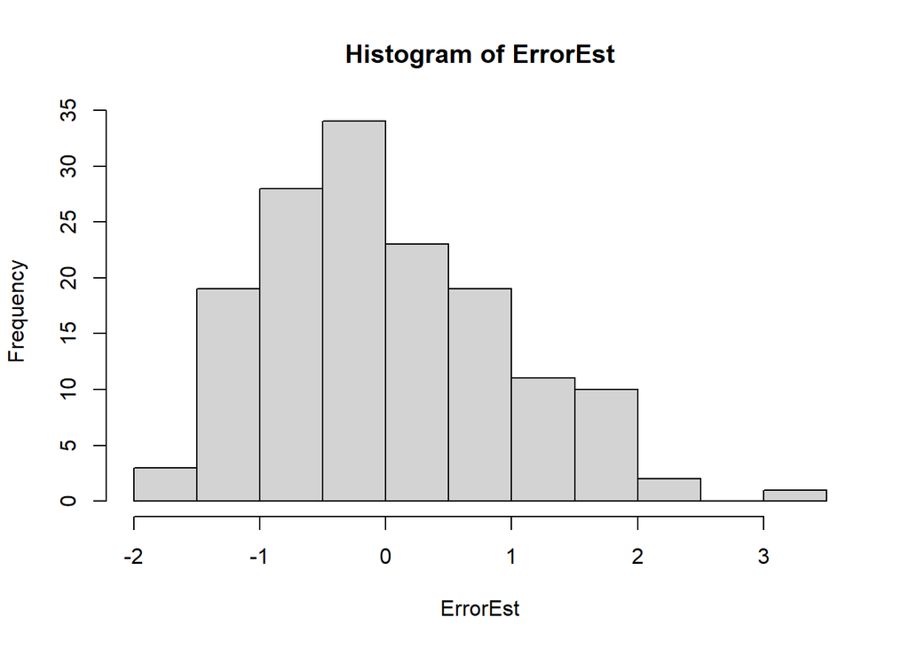

```r
ErrorEst <- Y-Ygorro
hist(ErrorEst)
```

```r
# >>==<< >>==<< >>==<< >>==<< >>==<< >>==<< >>==<<

x <- MiRegresion(X1,Y1)
# >>==<< >>==<< >>==<< >>==<< >>==<< >>==<< >>==<<
X1 <- rnorm(numvar);      print(X1)
```

```
##   [1] -0.820986697 -0.307257233 -0.902098009  0.627068743  1.120355028
##   [6]  2.127213552  0.366114383 -0.874781377  1.024474863  0.904758894
##  [11] -0.238248696 -1.557854904  0.761309895  1.129144396 -0.295107831
##  [16]  0.536242818 -0.275890475  0.682315245 -0.117290715 -0.344675864
##  [21]  0.111620498 -0.283405315 -0.591017164 -0.315936931 -0.008152152
##  [26]  0.207495141  1.532423622 -1.357997831 -0.199619051  0.631523128
##  [31]  1.762020903  0.426014363 -0.013753416 -0.307556910  0.414308164
##  [36]  0.989057920 -0.183858311  0.163761407  0.216936344  0.729277634
##  [41]  1.111380407  0.279160817 -0.076170672  1.394663132  0.164534118
##  [46]  1.577851979 -0.061922658  0.613922964 -1.546088594 -0.112391961
##  [51] -0.021794540 -0.758345417 -1.035892884  0.948159303  0.914158734
##  [56] -1.298731995  0.424378795 -1.112545320 -1.051073226  0.525412448
##  [61] -0.686024000  0.993479982  0.038523599  0.536148976 -0.523626698
##  [66] -1.151221335  0.914752241  0.238071492 -0.239067759  0.069235327
##  [71]  1.325908343 -0.698166635 -0.749408444 -0.619615053 -1.584991268
##  [76]  0.819628138  0.192369647  0.207171974 -0.043347354 -0.510160441
##  [81] -0.823418614  0.851856403 -1.426184673  0.440298942 -0.792611651
##  [86]  0.282310215 -0.740690522 -0.523341683  1.769365917  0.668282619
##  [91] -2.144897024  0.126412416 -0.451812936 -1.136626188  0.209785890
##  [96]  0.129965516 -0.328506573  1.972703567 -2.248690067  0.838219387
## [101] -0.289023270  0.656513411 -0.453997701 -0.593864562 -1.710379666
## [106] -0.209448428  2.478745801  0.989702208  1.675572156  0.914965318
## [111]  1.144262708  0.902876414  0.475392432 -0.582528774 -0.532934737
## [116] -1.600839996 -0.005817714  0.899355676  1.031922557  0.095132704
## [121] -0.547627617  3.290517443  0.736685531  1.420575305 -0.337680641
## [126] -0.037957627  0.448607098  1.676522312 -0.311474545  0.853615667
## [131] -2.094814634 -0.507254434 -1.292009077  1.113362717 -0.164453088
## [136] -0.390374082  1.369099846  1.116272858 -0.898021203  0.427866488
## [141] -1.228444569 -0.475615024  1.616577637  1.450127951  1.109018755
## [146] -0.570903886 -1.881431470 -1.175698184  0.952556525 -0.290567886
```

```r
Y1 <- X1+rnorm(numvar); print(Y1)
```

```
##   [1] -2.98359484 -0.48744472  0.50814121  1.27053738  0.29909648  0.58129690
##   [7] -0.46043284 -0.84025371  1.91254856 -1.03518126  0.78495306 -1.55239718
##  [13]  1.33108886 -0.52411117 -0.96176221  0.08800863  0.76800087  1.71048929
##  [19]  0.31779974  1.25953632 -0.40379070  0.72913188 -0.62695719 -0.98327903
##  [25]  0.91522789  1.58859547  2.41067404 -1.86740129 -0.66940668  2.00919897
##  [31]  2.11484731  1.25558834 -0.35245540  0.95347803 -0.39444698  1.61440944
##  [37] -1.00103328 -2.29881361 -1.12602117  0.86557283  1.99430316 -1.47214127
##  [43] -1.32759514  3.15920913 -0.26936523  2.08355211 -0.58885798  0.31534008
##  [49] -1.45884439 -0.10143012 -0.21435475 -1.22814190 -4.08375377  2.81681480
##  [55]  2.70458294 -2.39981374  0.25627127  0.26272998 -0.05278320  1.80201407
##  [61] -1.75777092  3.57074808 -1.09493636  1.29006532 -0.38235072 -1.55493165
##  [67]  0.53533644 -0.75332532  1.38359204  0.15874855  1.58512629 -0.48853380
##  [73] -1.12457920 -1.75363630 -1.33126496 -1.27401131 -1.22619730 -0.86922472
##  [79] -1.12202622 -0.40297162  0.77506893 -0.66346774 -0.99250865  1.33984370
##  [85] -1.78214385  0.22951081  0.08292038 -0.77885079  1.54868157  0.97600941
##  [91] -2.20491028 -0.42924047 -0.59042796  0.74621360  1.08345457 -0.78463156
##  [97] -1.57342419  1.61272133 -0.91991537  1.13089851 -0.99052851  1.53874798
## [103] -0.58736809 -1.71454306 -1.24918721  1.31469438  2.91321410  1.18170258
## [109]  1.01932903  1.48336385  0.07369217 -0.75027261  0.43203966 -0.61712228
## [115]  1.83212079 -2.81718730  0.16508861  1.70440877  2.08251540  0.08440822
## [121] -1.29088376  3.22473339  2.67644152  1.90331431 -2.38215771  1.38550150
## [127]  0.98910976  1.64295054 -0.32933817  0.70382595 -1.83825515 -1.01112137
## [133] -1.01499783  0.18200669  0.03569379  0.71646334  1.87830596  2.15002253
## [139] -1.98888997  0.48265927 -0.61119427 -1.54361989  3.18239197  0.41531994
## [145]  1.27353746 -0.41907156 -1.75976117 -1.38612277  1.40249331 -1.32173238
```

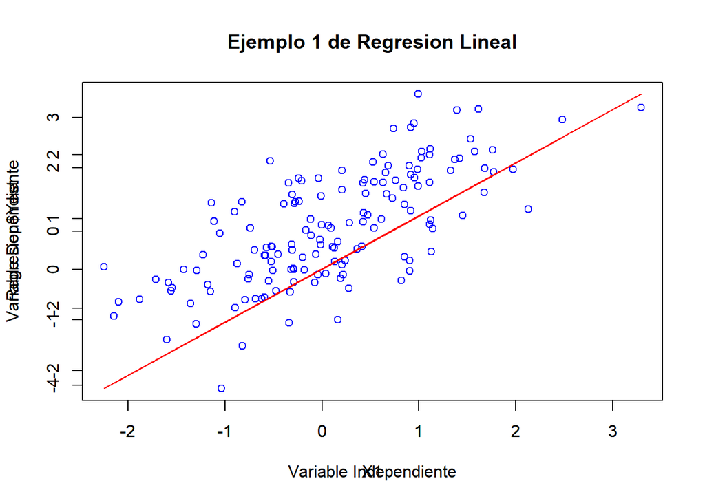

```r
Regresion <- MiRegresion(X1,Y1)
plot(X1,Y1,main= 'Ejemplo 1 de Regresion Lineal',
     xlab = 'Variable Independiente',
     ylab = 'Variable Dependiente',
     col = 'blue',
     type = 'p')
par(new=TRUE)
plot(X1,Regresion$Yest,col='red',type='l')
```

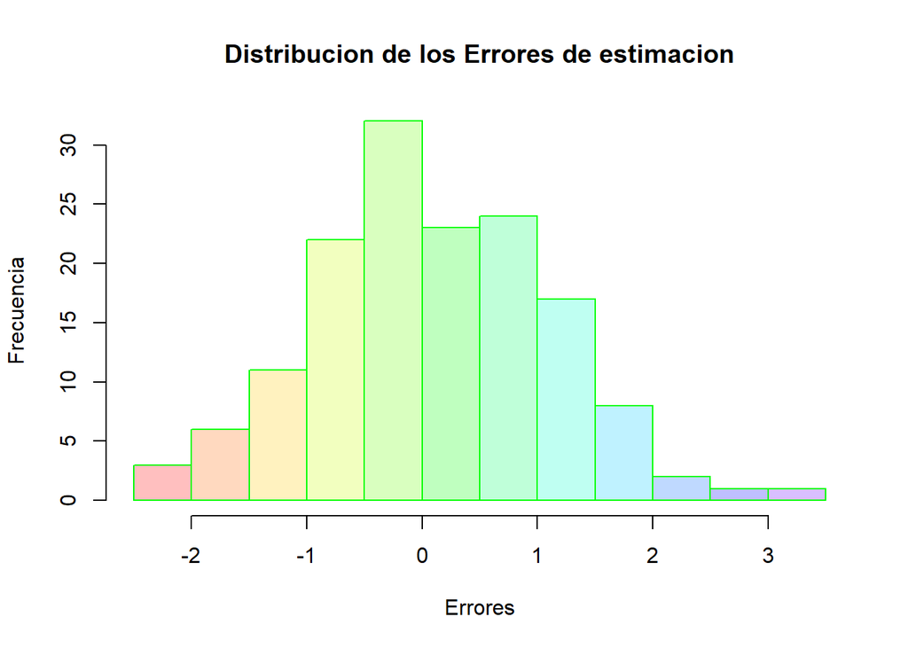

```r
Ygorro <- Regresion$Yest
hist(Ygorro, main='Distribucion de los Errores de estimacion',
     xlab='Errores',
     ylab= 'Frecuencia',
     col = rainbow(15, 0.25),
     border = 'green')
```

# sesion 9

INTERVALOS DE CONFIANZA pARA UNA MEDA

```r
#a) P[X>3]
x0<-2; mu<-2; desvest <-1/3;
z0= (x0-mu)/desvest;print(z0)
```

```
## [1] 0
```

```r
probabilidad <- pnorm(z0,0,1);print(probabilidad)
```

```
## [1] 0.5
```

```r
probbuscada<- 1-probabilidad;print(probbuscada)
```

```
## [1] 0.5
```

```r
#------------------------------------------------
#b) P[2<X<3]
x1<-2; mu<-2; desvest <-1/3;
z1= (x1-mu)/desvest; print(z1)
```

```
## [1] 0
```

```r
p1 <-pnorm(z1,0,1); print(p1)
```

```
## [1] 0.5
```

```r
x2<-3;
z2 = (x2-mu)/desvest; print(z2)
```

```
## [1] 3
```

```r
p2<-pnorm(z2,0,1);print(p2)
```

```
## [1] 0.9986501
```

```r
probbuscada<-p2-p1; print(probbuscada)
```

```
## [1] 0.4986501
```

```r
#------------------------------------------------
#c)encontrar x0 tal que P[X>x0]=0.45
#qnorm busca en el cuartil en las tablas (0.45,0,1)
#P[X>x*]=p* entonces buscamos en tablas el valor de x*, talque
#P[X<x*]=q*=1-p*, esto se hace con la funcion qnorm(q*,0,1)
pestrella<-0.45; qestrella=1-pestrella; print(qestrella)
```

```
## [1] 0.55
```

```r
zestrella<-qnorm(qestrella,0,1); print(zestrella)
```

```
## [1] 0.1256613
```

```r
#c0orroboramos
pnorm(zestrella,0,1)
```

```
## [1] 0.55
```

```r
mu<-2; desvest<-1/3;
xestrella<-mu+desvest*zestrella; print(xestrella)
```

```
## [1] 2.041887
```

```r
pnorm(xestrella,2,1/3)
```

```
## [1] 0.55
```

```r
#------------------------------------------------
#d) encontrar x* tal que P[X<x*]= alfa
#i)alfa = 0.5;    ii)alfa=0.75;
#iii)alfa = 0.8;  iv) alfa=0.85;
#v)alfa= 0.9;     vi)alfa=0.95;
#vii)alfa=0.99;
#-------
#i)alfa = 0.5;
mu<-2; desvest<-1/3;
alfa1<-0.75
t1<-qnorm(alfa1,0,1); print(t1)
```

```
## [1] 0.6744898
```

```r
mu<-2; desvest<-1/3;
x1<-mu+desvest*t1; print(x1)
```

```
## [1] 2.22483
```

```r
#--------
#ii)alfa=0.75;
mu<-2; desvest<-1/3;
alfa2<-0.875
t2<-qnorm(alfa2,0,1); print(t2)
```

```
## [1] 1.150349
```

```r
mu<-2; desvest<-1/3;
x2<-mu+desvest*t2; print(x2)
```

```
## [1] 2.38345
```

```r
#---------
#iii)alfa=0.8;
mu<-2; desvest<-1/3;
alfa3<-0.9
t3<-qnorm(alfa3,0,1); print(t3)
```

```
## [1] 1.281552
```

```r
mu<-2; desvest<-1/3;
x3<-mu+desvest*t3; print(x3)
```

```
## [1] 2.427184
```

```r
#-----------
#iv) alfa=0.85;
mu<-2; desvest<-1/3;
alfa4<-0.925
t4<-qnorm(alfa4,0,1); print(t4)
```

```
## [1] 1.439531
```

```r
mu<-2; desvest<-1/3;
x4<-mu+desvest*t4; print(x4)
```

```
## [1] 2.479844
```

```r
#------------
#v)alfa= 0.9;
mu<-2; desvest<-1/3;
alfa5<-0.95
t5<-qnorm(alfa5,0,1); print(t5)
```

```
## [1] 1.644854
```

```r
mu<-2; desvest<-1/3;
x5<-mu+desvest*t5; print(x5)
```

```
## [1] 2.548285
```

```r
#-------
#vi)alfa=0.95;
mu<-2; desvest<-1/3;
alfa6<-0.975
t6<-qnorm(alfa6,0,1); print(t6)
```

```
## [1] 1.959964
```

```r
mu<-2; desvest<-1/3;
x6<-mu+desvest*t6; print(x6)
```

```
## [1] 2.653321
```

```r
#------------------
#vii)alfa=0.99;
mu<-2; desvest<-1/3;
alfa7<-0.995
t7<-qnorm(alfa7,0,1); print(t7)
```

```
## [1] 2.575829
```

```r
mu<-2; desvest<-1/3;
x7<-mu+desvest*t7; print(x7)
```

```
## [1] 2.85861
```

```r
#------#
Resultados<- matrix(0,7,5)
Resultados[,1]<-c(alfa1, alfa2, alfa3, alfa4, alfa5, alfa6, alfa7)
Resultados[,3]<-c(t1,t2,t3,t4,t5,t6,t7);print(Resultados)
```

```
##       [,1] [,2]      [,3] [,4] [,5]
## [1,] 0.750    0 0.6744898    0    0
## [2,] 0.875    0 1.1503494    0    0
## [3,] 0.900    0 1.2815516    0    0
## [4,] 0.925    0 1.4395315    0    0
## [5,] 0.950    0 1.6448536    0    0
## [6,] 0.975    0 1.9599640    0    0
## [7,] 0.995    0 2.5758293    0    0
```

```r
Resultados[,2]<- -Resultados[,3]
Resultados[,5]<-c(x1,x2,x3,x4,x5,x6,x7);print(Resultados)
```

```
##       [,1]       [,2]      [,3] [,4]     [,5]
## [1,] 0.750 -0.6744898 0.6744898    0 2.224830
## [2,] 0.875 -1.1503494 1.1503494    0 2.383450
## [3,] 0.900 -1.2815516 1.2815516    0 2.427184
## [4,] 0.925 -1.4395315 1.4395315    0 2.479844
## [5,] 0.950 -1.6448536 1.6448536    0 2.548285
## [6,] 0.975 -1.9599640 1.9599640    0 2.653321
## [7,] 0.995 -2.5758293 2.5758293    0 2.858610
```

```r
Resultados[,4]<- -Resultados[,5]
colnames (Resultados)<- c('confianza','-t*','t*','-x*','x*'); print(Resultados)
```

```
##      confianza        -t*        t*       -x*       x*
## [1,]     0.750 -0.6744898 0.6744898 -2.224830 2.224830
## [2,]     0.875 -1.1503494 1.1503494 -2.383450 2.383450
## [3,]     0.900 -1.2815516 1.2815516 -2.427184 2.427184
## [4,]     0.925 -1.4395315 1.4395315 -2.479844 2.479844
## [5,]     0.950 -1.6448536 1.6448536 -2.548285 2.548285
## [6,]     0.975 -1.9599640 1.9599640 -2.653321 2.653321
## [7,]     0.995 -2.5758293 2.5758293 -2.858610 2.858610
```

```r
rownames (Resultados) <-c(1,2,3,4,5,6,7);print(Resultados)
```

```
##   confianza        -t*        t*       -x*       x*
## 1     0.750 -0.6744898 0.6744898 -2.224830 2.224830
## 2     0.875 -1.1503494 1.1503494 -2.383450 2.383450
## 3     0.900 -1.2815516 1.2815516 -2.427184 2.427184
## 4     0.925 -1.4395315 1.4395315 -2.479844 2.479844
## 5     0.950 -1.6448536 1.6448536 -2.548285 2.548285
## 6     0.975 -1.9599640 1.9599640 -2.653321 2.653321
## 7     0.995 -2.5758293 2.5758293 -2.858610 2.858610
```

```r
#--------------------------------------------------------
#e) P[X<0];
x3<- 0; mu<-2; desvest <-1/3;
z3= (x3-mu)/desvest;print(z3)
```

```
## [1] -6
```

```r
probabilidad <- pnorm(z3,0,1);print(probabilidad)
```

```
## [1] 9.865876e-10
```

```r
#-------------------------------------------------
#f) P[-1<x<1];
x4<- -1; mu<-2; desvest <-1/3;
z4= (x4-mu)/desvest; print(z4)
```

```
## [1] -9
```

```r
p3 <-pnorm(z4,0,1); print(p3)
```

```
## [1] 1.128588e-19
```

```r
x5<-1;
z5 = (x5-mu)/desvest; print(z5)
```

```
## [1] -3
```

```r
p4<-pnorm(z5,0,1);print(p4)
```

```
## [1] 0.001349898
```

# Sesion 10-12

Para 2 colas

```r
mu <- 2;   desvest <- 1/3;
# << >> << >> << >> << >> << >> << >> << >> << >> << >> << >>
alfa1 <- 0.75;
zest1 <- qnorm(alfa1,0,1); print(zest1)
```

```
## [1] 0.6744898
```

```r
xest1 <- mu+desvest*zest1; print(xest1)
```

```
## [1] 2.22483
```

```r
# ----------------------------- ----------------------------- ------------------
alfa2 <- 0.875;
zest2 <- qnorm(alfa2,0,1); print(zest2)
```

```
## [1] 1.150349
```

```r
xest2 <- mu+desvest*zest2; print(xest2)
```

```
## [1] 2.38345
```

```r
# ----------------------------- ----------------------------- ------------------
alfa3 <- 0.9;
zest3 <- qnorm(alfa3,0,1); print(zest3)
```

```
## [1] 1.281552
```

```r
xest3 <- mu+desvest*zest3; print(xest3)
```

```
## [1] 2.427184
```

```r
# ----------------------------- ----------------------------- ------------------
alfa4 <- 0.925;
zest4 <- qnorm(alfa4,0,1); print(zest4)
```

```
## [1] 1.439531
```

```r
xest4 <- mu+desvest*zest4; print(xest4)
```

```
## [1] 2.479844
```

```r
# ----------------------------- ----------------------------- ------------------
alfa5 <- 0.95;
zest5 <- qnorm(alfa5,0,1); print(zest5)
```

```
## [1] 1.644854
```

```r
xest5 <- mu+desvest*zest5; print(xest5)
```

```
## [1] 2.548285
```

```r
# ----------------------------- ----------------------------- ------------------
alfa6 <- 0.975;
zest6 <- qnorm(alfa6,0,1); print(zest6)
```

```
## [1] 1.959964
```

```r
xest6 <- mu+desvest*zest6; print(xest6)
```

```
## [1] 2.653321
```

```r
# ----------------------------- ----------------------------- ------------------
alfa7 <- 0.995;
zest7 <- qnorm(alfa7,0,1); print(zest7)
```

```
## [1] 2.575829
```

```r
xest7 <- mu+desvest*zest7; print(xest7)
```

```
## [1] 2.85861
```

```r
# ----------------------------- ----------------------------- ------------------
Resultados <- matrix(0,7,5)
Resultados[,1] <- c(alfa1, alfa2, alfa3, alfa4, alfa5, alfa6, alfa7); print(Resultados)
```

```
##       [,1] [,2] [,3] [,4] [,5]
## [1,] 0.750    0    0    0    0
## [2,] 0.875    0    0    0    0
## [3,] 0.900    0    0    0    0
## [4,] 0.925    0    0    0    0
## [5,] 0.950    0    0    0    0
## [6,] 0.975    0    0    0    0
## [7,] 0.995    0    0    0    0
```

```r
Resultados[,3] <- c(zest1,zest2,zest3,zest4,zest5,zest6,zest7); print(Resultados)
```

```
##       [,1] [,2]      [,3] [,4] [,5]
## [1,] 0.750    0 0.6744898    0    0
## [2,] 0.875    0 1.1503494    0    0
## [3,] 0.900    0 1.2815516    0    0
## [4,] 0.925    0 1.4395315    0    0
## [5,] 0.950    0 1.6448536    0    0
## [6,] 0.975    0 1.9599640    0    0
## [7,] 0.995    0 2.5758293    0    0
```

```r
Resultados[,2] <- -Resultados[,3]
Resultados[,5] <- c(xest1,xest2,xest3,xest4,xest5,xest6,xest7); print(Resultados)
```

```
##       [,1]       [,2]      [,3] [,4]     [,5]
## [1,] 0.750 -0.6744898 0.6744898    0 2.224830
## [2,] 0.875 -1.1503494 1.1503494    0 2.383450
## [3,] 0.900 -1.2815516 1.2815516    0 2.427184
## [4,] 0.925 -1.4395315 1.4395315    0 2.479844
## [5,] 0.950 -1.6448536 1.6448536    0 2.548285
## [6,] 0.975 -1.9599640 1.9599640    0 2.653321
## [7,] 0.995 -2.5758293 2.5758293    0 2.858610
```

```r
Resultados[,4] <- -Resultados[,5]
colnames(Resultados) <- c('Confianza','*-z*','z*','-x*','x*'); print(Resultados)
```

```
##      Confianza       *-z*        z*       -x*       x*
## [1,]     0.750 -0.6744898 0.6744898 -2.224830 2.224830
## [2,]     0.875 -1.1503494 1.1503494 -2.383450 2.383450
## [3,]     0.900 -1.2815516 1.2815516 -2.427184 2.427184
## [4,]     0.925 -1.4395315 1.4395315 -2.479844 2.479844
## [5,]     0.950 -1.6448536 1.6448536 -2.548285 2.548285
## [6,]     0.975 -1.9599640 1.9599640 -2.653321 2.653321
## [7,]     0.995 -2.5758293 2.5758293 -2.858610 2.858610
```

```r
rownames(Resultados) <- c(1,2,3,4,5,6,7); print(Resultados)
```

```
##   Confianza       *-z*        z*       -x*       x*
## 1     0.750 -0.6744898 0.6744898 -2.224830 2.224830
## 2     0.875 -1.1503494 1.1503494 -2.383450 2.383450
## 3     0.900 -1.2815516 1.2815516 -2.427184 2.427184
## 4     0.925 -1.4395315 1.4395315 -2.479844 2.479844
## 5     0.950 -1.6448536 1.6448536 -2.548285 2.548285
## 6     0.975 -1.9599640 1.9599640 -2.653321 2.653321
## 7     0.995 -2.5758293 2.5758293 -2.858610 2.858610
```

```r
# ----------------------------- ----------------------------- ------------------
indices <- c(1,3)
renglones <- c(5,6,7)
ValoresZ <- Resultados[renglones,indices]
print(ValoresZ)
```

```
##   Confianza       z*
## 5     0.950 1.644854
## 6     0.975 1.959964
## 7     0.995 2.575829
```

```r
rownames(ValoresZ) <- c('90%','95%','99%')
print(ValoresZ)
```

```
##     Confianza       z*
## 90%     0.950 1.644854
## 95%     0.975 1.959964
## 99%     0.995 2.575829
```

Intervalo de confiaza muestras grandes

```r
DesvEst <- 8
n <- 100
xbarra <- 170
alpha <- 90; Zalpha1 <- 1.64
alpha <- 95; Zalpha2 <- 1.96
alpha <- 99; Zalpha3 <- 2.57

mu1 <- xbarra - Zalpha2*(DesvEst/sqrt(n)); print(mu1)
```

```
## [1] 168.432
```

```r
mu2 <- xbarra + Zalpha2*(DesvEst/sqrt(n)); print(mu2)
```

```
## [1] 171.568
```

```r
Intervalo <- paste0("mu ∈  ","(",mu1,",",mu2,")");
print(Intervalo)
```

```
## [1] "mu ∈  (168.432,171.568)"
```

```r
# Ejercicio 2

DesvEst <- 10
n <- 50
xbarra <- 400
alpha <- 90; Zalpha1 <- 1.64
alpha <- 95; Zalpha2 <- 1.96
alpha <- 99; Zalpha3 <- 2.57

mu1 <- xbarra - Zalpha1*(DesvEst/sqrt(n)); print(mu1)
```

```
## [1] 397.6807
```

```r
mu2 <- xbarra + Zalpha1*(DesvEst/sqrt(n)); print(mu2)
```

```
## [1] 402.3193
```

```r
Intervalo <- paste0("mu ∈  ","(",mu1,",",mu2,")");
print(Intervalo)
```

```
## [1] "mu ∈  (397.680689757708,402.319310242292)"
```

```r
Intervalo <- paste0("mu ∈  ","(",round(mu1,2),",",round(mu2,2),")");
print(Intervalo)
```

```
## [1] "mu ∈  (397.68,402.32)"
```

```r
# ejercicio 3
# Intervalo de confianza del   95
# para la media de las alturas de una población de   2000
# estudiantes universitarios:
#  Media muestral : 170 cm
# Desviación estándar muestral s: 10 cm

DesvEst <- 10
n <- 2000
xbarra <- 170
alpha <- 90; Zalpha1 <- 1.64
alpha <- 95; Zalpha2 <- 1.96
alpha <- 99; Zalpha3 <- 2.57

mu1 <- xbarra - Zalpha2*(DesvEst/sqrt(n)); print(mu1)
```

```
## [1] 169.5617
```

```r
mu2 <- xbarra + Zalpha2*(DesvEst/sqrt(n)); print(mu2)
```

```
## [1] 170.4383
```

```r
Intervalo <- paste0("mu ∈  ","(",round(mu1,2),",",round(mu2,2),")");
print(Intervalo)
```

```
## [1] "mu ∈  (169.56,170.44)"
```

Intervalos de confianza muestras chicas

```r
#tamaño de la muestra (n): 10
#Media muestral ( xˉ): 170 cm
#Desviación estándar muestral ( s): 8 cm
#Nivel de confianza:  95
n <- 10
xbarra <- 170
DesvEst <- 8
gl <- n-1
nc <- 0.975

Talpha2 <- round(qt(nc, gl),4)
mu1 <- xbarra - Talpha2*(DesvEst/sqrt(n));
mu2 <- xbarra + Talpha2*(DesvEst/sqrt(n));
Intervalo <- paste0("mu ∈  ","(",round(mu1,2),",",
                    round(mu2,2),")");
print(Intervalo)
```

```
## [1] "mu ∈  (164.28,175.72)"
```

```r
# ------------------------------------------------------------
#tamaño de la muestra (n): 10
#Media muestral ( xˉ): 170 cm
#Desviación estándar muestral ( s): 8 cm
#Nivel de confianza:  95
n <- 15
xbarra <- 3.5
DesvEst <- 0.5
gl <- n-1
nc <- 0.95

Talpha2 <- round(qt(nc, gl),4)
mu1 <- xbarra - Talpha2*(DesvEst/sqrt(n));
mu2 <- xbarra + Talpha2*(DesvEst/sqrt(n));
Intervalo <- paste0("mu ∈  ","(",round(mu1,2),",",round(mu2,2),")");
print(Intervalo)
```

```
## [1] "mu ∈  (3.27,3.73)"
```

Diderencia de 2 medias muestras grandes con varianza conocidas e iguales

```r
#problema 1
DesvEst<-0.8
n1<-50
n2<-50
x1barra<-3.5
x2barra<-4.2
barrax <- x1barra-x2barra
alpha <- 90;    Zalpha1<-1.64;
alpha <- 95;   Zalpha2<-1.96;
alpha <- 99;    Zalpha3<-2.57;

nc<-Zalpha2
errorstd<-DesvEst*sqrt((n1+n2)/(n1*n2))
errorstd<-DesvEst*sqrt((1/n1)+(1/n2))
liminf<-barrax-nc*errorstd; print(liminf)
```

```
## [1] -1.0136
```

```r
limsup<-barrax+nc*errorstd; print(limsup)
```

```
## [1] -0.3864
```

```r
Intervalo<- paste0("mu E ","(",round(liminf,2),",",round(limsup,2),")");
print(Intervalo)
```

```
## [1] "mu E (-1.01,-0.39)"
```

Varianzas desconocidas e iguales

```r
n1 <- 10
n2 <- 12
xbarra1 <- 6.5
xbarra2 <- 5.8
S1 <- 0.7
S2 <- 0.9
xbarra <- xbarra1-xbarra2
nc <- 0.975
Sd <- sqrt(((n1-1)*S1^2+(n2-1)*S2^2)/(n1+n2-2))
gl = n1+n2-2
Talpha2 <- round(qt(nc, gl),4)
LimInf <- xbarra - Talpha2*(Sd);
LimSup <- xbarra + Talpha2*(Sd);
Intervalo <- paste0("mu ∈  ","(",
                    round(LimInf,2),
                    ",",
                    round(LimSup,2),
                    ")");
print(Intervalo)
```

```
## [1] "mu ∈  (-1,2.4)"
```

Varianzas desconocidas y distintas

```r
# Se quiere comparar la efectividad de dos medicamentos para el dolor de cabeza.
# Se toma una muestra de 10 pacientes para el medicamento A y otra
# muestra de 12 pacientes para el medicamento B. Los resultados muestran que la
# media del medicamento A es de 6.5 y la media del medicamento B es de 5.8.
# Las desviaciones estándar son de 0.7 para el medicamento A y
# 0.9 para el medicamento B.
#Construya un intervalo de confianza del 95% para la diferencia de medias.

n1 <- 10
n2 <- 12
xbarra1 <- 6.5
xbarra2 <- 5.8
S1 <- 0.7
S2 <- 0.9
xbarra <- xbarra1-xbarra2
nc <- 0.975
Sd <- sqrt(((S1^2)/n1)+((S2^2)/n2))

numerador <- (((S1^2)/n1)+((S2^2)/n2))^2
denominador <- ((((S1^2)/n1)^2)/(n1-1))+((((S2^2)/n2)^2)/(n2-1))
gl = ceiling(numerador/denominador)
Talpha2 <- round(qt(nc, gl),4)

LimInf <- xbarra - Talpha2*(Sd);
LimSup <- xbarra + Talpha2*(Sd);
Intervalo <- paste0("mu ∈  ","(",
                    round(LimInf,2),
                    ",",
                    round(LimSup,2),
                    ")");
print(Intervalo)
```

```
## [1] "mu ∈  (-0.01,1.41)"
```